# LAB OF INFORMATION SYSTEMS AND ANALYTICS- PROJECT

# DEVELOPED BY ANDREA SCORDARI - 895104

To begin the project, I installed and imported all the necessary libraries required for data manipulation, visualization, and modeling. These libraries include tools for data handling, statistical analysis, and machine learning, ensuring a comprehensive environment for conducting the analysis effectively.

```python
!pip install pandas
!pip install numpy
!pip install matplotlib
!pip install seaborn
!pip install joypy
```

```python
# Importing necessary libraries
import pandas as pd
import numpy as np
import matplotlib.pyplot as plt
import seaborn as sns
import scipy.stats as stats
import plotly.graph_objs as go
import plotly.express as px
import warnings
import importlib

from sklearn.feature_selection import RFECV
from sklearn.neural_network import MLPRegressor
from sklearn.metrics import mean_squared_error, mean_absolute_error, r2_score
from sklearn.feature_selection import RFE
from plotly.subplots import make_subplots
from datetime import datetime
from sklearn.linear_model import LinearRegression
from sklearn.model_selection import train_test_split, GridSearchCV
from sklearn.preprocessing import StandardScaler, OneHotEncoder, MinMaxScaler
from sklearn.preprocessing import PolynomialFeatures
from sklearn.compose import ColumnTransformer
from sklearn.pipeline import Pipeline
from sklearn.ensemble import RandomForestRegressor, GradientBoostingRegressor
from sklearn.svm import SVR
from sklearn.inspection import PartialDependenceDisplay
from mpl_toolkits.mplot3d import Axes3D
from statsmodels.stats.outliers_influence import variance_inflation_factor
from sklearn.decomposition import PCA



# Suppress specific warnings, like FutureWarning and DeprecationWarning
warnings.filterwarnings('ignore', category=FutureWarning)
warnings.filterwarnings('ignore', category=DeprecationWarning)
```

# DATA LOADING AND INSPECTION

```python
# Load the dataset
file_path = 'SeoulBikeData.csv'
bike_data = pd.read_csv(file_path, encoding='ISO-8859-1')

# Display the dataset
bike_data
```

|  | Date | Rented Bike Count | Hour | Temperature(°C) | Humidity(%) | Wind speed (m/s) | Visibility (10m) | Dew point temperature(°C) | Solar Radiation (MJ/m2) | Rainfall(mm) | Snowfall (cm) | Seasons | Holiday | Functioning Day |
| --- | --- | --- | --- | --- | --- | --- | --- | --- | --- | --- | --- | --- | --- | --- |
| 0 | 01/12/2017 | 254 | 0 | -5.2 | 37 | 2.2 | 2000 | -17.6 | 0.0 | 0.0 | 0.0 | Winter | No Holiday | Yes |
| 1 | 01/12/2017 | 204 | 1 | -5.5 | 38 | 0.8 | 2000 | -17.6 | 0.0 | 0.0 | 0.0 | Winter | No Holiday | Yes |
| 2 | 01/12/2017 | 173 | 2 | -6.0 | 39 | 1.0 | 2000 | -17.7 | 0.0 | 0.0 | 0.0 | Winter | No Holiday | Yes |
| 3 | 01/12/2017 | 107 | 3 | -6.2 | 40 | 0.9 | 2000 | -17.6 | 0.0 | 0.0 | 0.0 | Winter | No Holiday | Yes |
| 4 | 01/12/2017 | 78 | 4 | -6.0 | 36 | 2.3 | 2000 | -18.6 | 0.0 | 0.0 | 0.0 | Winter | No Holiday | Yes |
| ... | ... | ... | ... | ... | ... | ... | ... | ... | ... | ... | ... | ... | ... | ... |
| 8755 | 30/11/2018 | 1003 | 19 | 4.2 | 34 | 2.6 | 1894 | -10.3 | 0.0 | 0.0 | 0.0 | Autumn | No Holiday | Yes |
| 8756 | 30/11/2018 | 764 | 20 | 3.4 | 37 | 2.3 | 2000 | -9.9 | 0.0 | 0.0 | 0.0 | Autumn | No Holiday | Yes |
| 8757 | 30/11/2018 | 694 | 21 | 2.6 | 39 | 0.3 | 1968 | -9.9 | 0.0 | 0.0 | 0.0 | Autumn | No Holiday | Yes |
| 8758 | 30/11/2018 | 712 | 22 | 2.1 | 41 | 1.0 | 1859 | -9.8 | 0.0 | 0.0 | 0.0 | Autumn | No Holiday | Yes |
| 8759 | 30/11/2018 | 584 | 23 | 1.9 | 43 | 1.3 | 1909 | -9.3 | 0.0 | 0.0 | 0.0 | Autumn | No Holiday | Yes |

8760 rows × 14 columns

# DATA CLEANING AND EXPLORATORY DATA ANALYSIS (EDA)

```python
# Verify how many clomuns and rows the dataset is composed by
print('The dataset has {} rows and {} columns.'.format(bike_data.shape[0], bike_data.shape[1]))
```

```
The dataset has 8760 rows and 14 columns.
```

```python
# Get a summary of the dataset
bike_data.info()

# Check data types
bike_data.dtypes
```

```
<class 'pandas.core.frame.DataFrame'>
RangeIndex: 8760 entries, 0 to 8759
Data columns (total 14 columns):
 #   Column                     Non-Null Count  Dtype
---  ------                     --------------  -----
 0   Date                       8760 non-null   object
 1   Rented Bike Count          8760 non-null   int64
 2   Hour                       8760 non-null   int64
 3   Temperature(°C)            8760 non-null   float64
 4   Humidity(%)                8760 non-null   int64
 5   Wind speed (m/s)           8760 non-null   float64
 6   Visibility (10m)           8760 non-null   int64
 7   Dew point temperature(°C)  8760 non-null   float64
 8   Solar Radiation (MJ/m2)    8760 non-null   float64
 9   Rainfall(mm)               8760 non-null   float64
 10  Snowfall (cm)              8760 non-null   float64
 11  Seasons                    8760 non-null   object
 12  Holiday                    8760 non-null   object
 13  Functioning Day            8760 non-null   object
dtypes: float64(6), int64(4), object(4)
memory usage: 958.3+ KB
```

```
Date                          object
Rented Bike Count              int64
Hour                           int64
Temperature(°C)              float64
Humidity(%)                    int64
Wind speed (m/s)             float64
Visibility (10m)               int64
Dew point temperature(°C)    float64
Solar Radiation (MJ/m2)      float64
Rainfall(mm)                 float64
Snowfall (cm)                float64
Seasons                       object
Holiday                       object
Functioning Day               object
dtype: object
```

```python
# Check for missing values
missing_values = bike_data.isnull().sum()
missing_values[missing_values > 0]

# Check if there is some NaN values
if (bike_data.isnull().values.any()) == True:
        print('There are NaN values in the dataset.')
else:
    print('There are no NaN values in the dataset.')
```

```
There are no NaN values in the dataset.
```

These outputs from the .info and .dtypes function provide a summary of the dataset's structure, including the total number of entries (8,760 rows) and columns (14 features). Features include a mix of integers (int64), floats (float64), and objects (object), indicating both numerical and categorical data types. The 'Date' column is an object type, requiring conversion to a datetime format for time-based analysis. After that I checked the presence of any missing values in any column. The output suggests the dataset is complete.

```python
# Display basic statistics
print(bike_data.describe())
```

```
       Rented Bike Count         Hour  Temperature(°C)  Humidity(%)  \
count        8760.000000  8760.000000      8760.000000  8760.000000
mean          704.602055    11.500000        12.882922    58.226256
std           644.997468     6.922582        11.944825    20.362413
min             0.000000     0.000000       -17.800000     0.000000
25%           191.000000     5.750000         3.500000    42.000000
50%           504.500000    11.500000        13.700000    57.000000
75%          1065.250000    17.250000        22.500000    74.000000
max          3556.000000    23.000000        39.400000    98.000000

       Wind speed (m/s)  Visibility (10m)  Dew point temperature(°C)  \
count       8760.000000       8760.000000                8760.000000
mean           1.724909       1436.825799                   4.073813
std            1.036300        608.298712                  13.060369
min            0.000000         27.000000                 -30.600000
25%            0.900000        940.000000                  -4.700000
50%            1.500000       1698.000000                   5.100000
75%            2.300000       2000.000000                  14.800000
max            7.400000       2000.000000                  27.200000

       Solar Radiation (MJ/m2)  Rainfall(mm)  Snowfall (cm)
count              8760.000000   8760.000000    8760.000000
mean                  0.569111      0.148687       0.075068
std                   0.868746      1.128193       0.436746
min                   0.000000      0.000000       0.000000
25%                   0.000000      0.000000       0.000000
50%                   0.010000      0.000000       0.000000
75%                   0.930000      0.000000       0.000000
max                   3.520000     35.000000       8.800000
```

This output shows basic statistical summaries for the numerical features in the dataset using the .describe() function. Key metrics include the count, mean, standard deviation, minimum, maximum, and percentile values (25%, 50%, and 75%) for each feature. Then I started handling my features:

```python
# Initialize lists to store feature names
nominal_features = []
ordinal_features = []
continuous_features = []
discrete_features = []

# Loop through the columns to classify them based on their data types
for col in bike_data.columns:
    if bike_data[col].dtype == 'object':
        nominal_features.append(col)
    elif bike_data[col].dtype == 'int64':
        discrete_features.append(col)
    elif bike_data[col].dtype == 'float64':
        continuous_features.append(col)
    else:
        ordinal_features.append(col)

# Print the counts of each feature type
print(f'There are {len(nominal_features)} nominal features, {len(ordinal_features)} ordinal features, {len(continuous_features)} continuous features, and {len(discrete_features)} discrete features.')

# Print the lists of columns with their data types
print("All Columns with Data Types:")
print(bike_data.dtypes)

# Automatically detect nominal features
auto_detected_nominal = bike_data.select_dtypes(include='object').columns.tolist()
print("Automatically Detected Nominal Features:", auto_detected_nominal)

# Compare with manually identified nominal features
print("Manually Identified Nominal Features:", nominal_features)

# Investigate any differences
missing_features = set(auto_detected_nominal) - set(nominal_features)
print("Missing Nominal Features:", missing_features)
```

```
There are 4 nominal features, 0 ordinal features, 6 continuous features, and 4 discrete features.
All Columns with Data Types:
Date                          object
Rented Bike Count              int64
Hour                           int64
Temperature(°C)              float64
Humidity(%)                    int64
Wind speed (m/s)             float64
Visibility (10m)               int64
Dew point temperature(°C)    float64
Solar Radiation (MJ/m2)      float64
Rainfall(mm)                 float64
Snowfall (cm)                float64
Seasons                       object
Holiday                       object
Functioning Day               object
dtype: object
Automatically Detected Nominal Features: ['Date', 'Seasons', 'Holiday', 'Functioning Day']
Manually Identified Nominal Features: ['Date', 'Seasons', 'Holiday', 'Functioning Day']
Missing Nominal Features: set()
```

```python
# Ensure the Date column is in the correct datetime format
bike_data['Date'] = pd.to_datetime(bike_data['Date'], format='%d/%m/%Y')

# Extract Year, Month, Day from the Date column
bike_data['Year'] = bike_data['Date'].dt.year
bike_data['Month'] = bike_data['Date'].dt.month
bike_data['Day'] = bike_data['Date'].dt.day

# Verify the changes
bike_data.head()
```

|  | Date | Rented Bike Count | Hour | Temperature(°C) | Humidity(%) | Wind speed (m/s) | Visibility (10m) | Dew point temperature(°C) | Solar Radiation (MJ/m2) | Rainfall(mm) | Snowfall (cm) | Seasons | Holiday | Functioning Day | Year | Month | Day |
| --- | --- | --- | --- | --- | --- | --- | --- | --- | --- | --- | --- | --- | --- | --- | --- | --- | --- |
| 0 | 2017-12-01 | 254 | 0 | -5.2 | 37 | 2.2 | 2000 | -17.6 | 0.0 | 0.0 | 0.0 | Winter | No Holiday | Yes | 2017 | 12 | 1 |
| 1 | 2017-12-01 | 204 | 1 | -5.5 | 38 | 0.8 | 2000 | -17.6 | 0.0 | 0.0 | 0.0 | Winter | No Holiday | Yes | 2017 | 12 | 1 |
| 2 | 2017-12-01 | 173 | 2 | -6.0 | 39 | 1.0 | 2000 | -17.7 | 0.0 | 0.0 | 0.0 | Winter | No Holiday | Yes | 2017 | 12 | 1 |
| 3 | 2017-12-01 | 107 | 3 | -6.2 | 40 | 0.9 | 2000 | -17.6 | 0.0 | 0.0 | 0.0 | Winter | No Holiday | Yes | 2017 | 12 | 1 |
| 4 | 2017-12-01 | 78 | 4 | -6.0 | 36 | 2.3 | 2000 | -18.6 | 0.0 | 0.0 | 0.0 | Winter | No Holiday | Yes | 2017 | 12 | 1 |

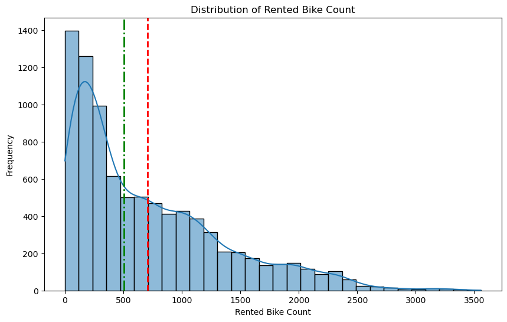

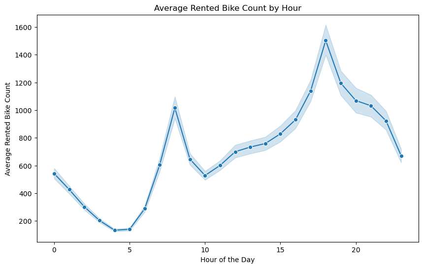

```python
# Visualize the distribution of the target variable 'Rented Bike Count'
plt.figure(figsize=(10, 6))
sns.histplot(bike_data['Rented Bike Count'], bins=30, kde=True)
plt.title('Distribution of Rented Bike Count')
plt.axvline(bike_data['Rented Bike Count'].mean(), color='red', linestyle='dashed', linewidth=2, label='Mean')
plt.axvline(bike_data['Rented Bike Count'].median(), color='green', linestyle='dashdot', linewidth=2, label='Median')
plt.xlabel('Rented Bike Count')
plt.ylabel('Frequency')
plt.show()

# Visualize the relationship between 'Hour' and 'Rented Bike Count'
plt.figure(figsize=(10, 6))
sns.lineplot(x='Hour', y='Rented Bike Count', data=bike_data, marker='o')
plt.title('Average Rented Bike Count by Hour')
plt.xlabel('Hour of the Day')
plt.ylabel('Average Rented Bike Count')
plt.show()
```

**Distribution of Rented Bike Count:** This plot shows the distribution of the bike rental counts, which is highly skewed to the right, indicating that most rentals are low in count with a few higher values. The green and red dashed lines represent different statistical measures (e.g., mean and median), highlighting that the mean is pulled towards the higher end due to outliers.

**Average Rented Bike Count by Hour:** This plot illustrates the average bike rentals by hour of the day, revealing peak rental times around 8 AM and 5-6 PM, corresponding to typical commuting hours. It suggests that bike rentals are heavily influenced by daily commute patterns, with lower rentals during non-commuting hours.

Here I processed nominal features to capture the categorical influences on bike rentals, focusing on skewness to decide whether to retain or remove certain variables. This approach allowed for addressing specific research questions and ensuring the model could effectively learn from these categorical features, enhancing its understanding of patterns related to seasonal and operational factors.

```python
# Nominal features
nominal_features = ['Seasons', 'Holiday', 'Functioning Day']

# Create a list to store the dictionaries, which I will convert to a DataFrame later
rows_list = []

# Define the threshold for considering skewness as "high"
threshold = 0.98

# Iterate over the nominal features
for col in nominal_features:
    mode = bike_data[col].mode()[0]
    mode_count = bike_data[col].value_counts()[mode]
    mode_prop = mode_count / bike_data.shape[0]

    # Determine if the skewness is high
    skewness = 'High' if mode_prop > threshold else 'Low'

    # Append the information to the list as a dictionary
    rows_list.append({
        'Feature': col,
        'Mode': mode,
        'Mode Count': mode_count,
        'Mode Proportion': mode_prop * 100,
        'Skewness': skewness
    })

# Convert the list of dictionaries to a DataFrame
mode_prop_df = pd.DataFrame(rows_list)

# Display the skewness information
print(mode_prop_df)
```

```
           Feature        Mode  Mode Count  Mode Proportion Skewness
0          Seasons      Spring        2208        25.205479      Low
1          Holiday  No Holiday        8328        95.068493      Low
2  Functioning Day         Yes        8465        96.632420      Low
```

The skewness analysis of the nominal features (Seasons, Holiday, and Functioning Day) indicates that all features have a "Low" skewness, meaning they are not overly dominated by a single category. Therefore, I have decided to retain these features for further analysis. Next step involves investigating the influence of these nominal variables on the target variable, Rented Bike Count. Specifically, I explored how seasonal variations, holidays, and functioning days impact bike rental demand.

**RESEARCH QUESTIONS**

- **Q1:** How does the distribution of bike rentals vary across different seasons?
- **Q2:** Is there a significant difference in bike rentals between holidays and non-holidays?
- **Q3:** Does the "Functioning Day" variable (whether it's a regular working day or not) significantly impact bike rentals?

# Q1 - DISTRIBUTION OF BIKE RENTALS ACROSS DIFFERENT SEASONS

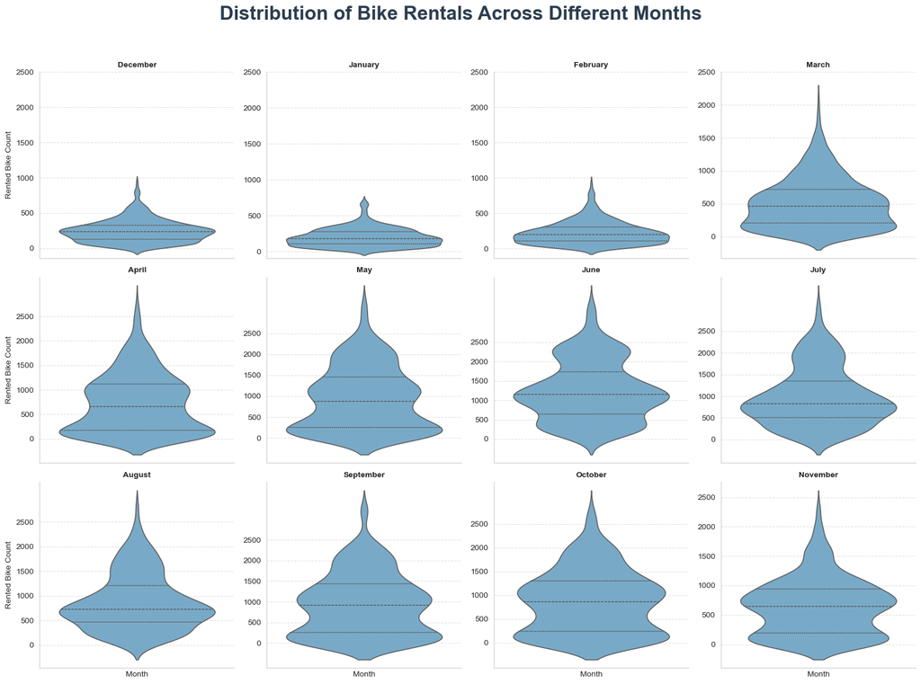

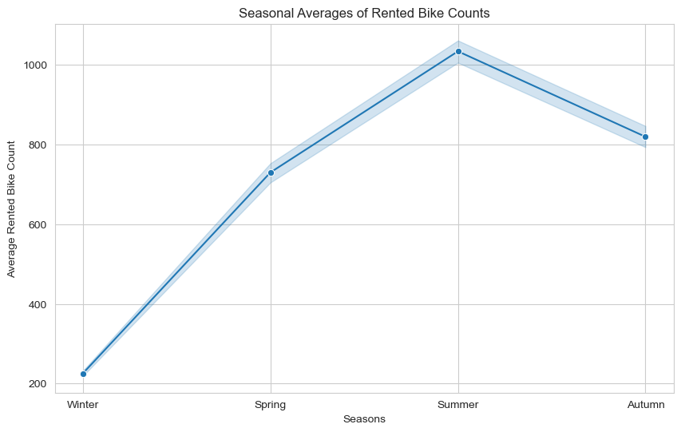

```
           count         mean         std   min     25%     50%      75%  \
Month
April      720.0   728.093056  598.379605   0.0  169.75   655.0  1118.50
August     744.0   876.192204  572.975581  10.0  466.75   732.5  1212.25
December   744.0   249.099462  158.396544   3.0  131.75   236.5   329.00
February   672.0   225.941964  160.665033   7.0  103.00   195.0   308.00
January    744.0   201.620968  127.180889  18.0  103.75   181.5   278.25
July       744.0   987.177419  666.348030   9.0  505.00   829.5  1352.50
June       720.0  1245.676389  769.050023   9.0  639.25  1144.5  1741.75
March      744.0   511.551075  377.850544   2.0  207.00   460.0   718.25
May        744.0   950.387097  749.465355   0.0  244.50   874.0  1464.00
November   720.0   646.826389  483.240662   0.0  195.00   650.0   942.25
October    744.0   874.563172  661.048202   0.0  248.25   870.0  1302.25
September  720.0   935.572222  745.310358   0.0  253.50   915.0  1438.50

              max
Month
April      2807.0
August     2836.0
December    937.0
February    929.0
January     702.0
July       3196.0
June       3556.0
March      2100.0
May        3251.0
November   2357.0
October    2857.0
September  3298.0
```

```python
# Extract the month names from the dates
bike_data['Month'] = bike_data['Date'].dt.month_name()

# Set a larger figure size
sns.set_style('whitegrid')
plt.figure(figsize=(20, 12))

# Set up the Facet Grid with subplots for each month using violin plots
g = sns.FacetGrid(bike_data, col="Month", col_wrap=4, height=4, sharex=False, sharey=False)

# Violin plots
g.map_dataframe(
    sns.violinplot,
    x="Month",
    y="Rented Bike Count",
    data=bike_data,
    inner="quart",
    hue="Month",
    legend=False,
    common_norm=True,
   density_norm='area',
    palette="Blues"
)
g.set_titles("{col_name}", fontsize=14, fontweight='bold')
g.set_axis_labels("Month", "Rented Bike Count")
g.fig.suptitle('Distribution of Bike Rentals Across Different Months', fontsize=24, fontweight='bold', color='#2c3e50')
g.set(xticks=[], yticks=[0, 500, 1000, 1500, 2000, 2500])
for ax in g.axes.flat:
    ax.grid(True, linestyle='--', alpha=0.6)

plt.tight_layout(rect=[0, 0, 1, 0.95])
plt.show()

# Plotting seasonal averages
plt.figure(figsize=(10, 6))
sns.lineplot(
    data=bike_data,
    x='Seasons',
    y='Rented Bike Count',
    marker='o'
)
plt.title('Seasonal Averages of Rented Bike Counts')
plt.xlabel('Seasons')
plt.ylabel('Average Rented Bike Count')
plt.show()

# Summary statistics for bike rentals by month
month_stats = bike_data.groupby('Month')['Rented Bike Count'].describe()
print(month_stats)
```

```python
# Grouping data by month and performing ANOVA
anova_results = stats.f_oneway(
    *(bike_data[bike_data['Month'] == month]['Rented Bike Count'] for month in bike_data['Month'].unique())
)

print("ANOVA Test Results for Bike Rentals Across Months")
print(f"F-statistic: {anova_results.statistic:.4f}, p-value: {anova_results.pvalue:.4f}")
```

```
ANOVA Test Results for Bike Rentals Across Months
F-statistic: 270.1788, p-value: 0.0000
```

The ANOVA test results indicate a significant difference in bike rentals across different months, as evidenced by the F-statistic of 270.1788 and a p-value of 0.0000. The very low p-value suggests that the variation in bike rentals between months is statistically significant, confirming that month-to-month changes are not due to random chance but reflect genuine differences in rental patterns.

The ANOVA test was run to determine if there are statistically significant differences in bike rentals across different months. By comparing the means of rented bike counts for each month, the test helps confirm whether variations observed in the data are due to genuine seasonal patterns rather than random fluctuations. The significant F-statistic and extremely low p-value indicate that monthly differences in rental counts are indeed significant.

```python
# Define a custom color palette for each season
custom_colors = {
    'Winter': 'royalblue',
    'Spring': 'limegreen',
    'Summer': 'tomato',
    'Autumn': 'orange'
}

# Create an interactive strip plot
fig = px.strip(
    bike_data,
    x='Seasons',
    y='Rented Bike Count',
    color='Seasons',
    color_discrete_map=custom_colors,
    hover_data=['Day','Month'],
    title='Interactive Strip Plot of Bike Rentals by Season',
    labels={'Rented Bike Count': 'Rented Bike Count', 'Seasons': 'Seasons'},
)

# Update layout for better appearance
fig.update_layout(
    template='plotly_white',
    xaxis_title='Seasons',
    yaxis_title='Rented Bike Count',
    legend_title='Seasons',
    showlegend=True
)
fig.show()
```

[interactive chart not shown]

**The Interactive Strip Plot** shows the distribution of bike rentals across different seasons. Each dot represents a bike rental count, color-coded by season. From the plot, we observe that:

- Winter generally has the lowest rental counts, with most data points concentrated at the lower end.
- Spring and Autumn show moderate rental counts with a wider spread, indicating a more varied rental pattern.
- Summer has the highest rental counts, with a clear upward shift in the distribution, indicating a peak in bike usage during this season.

# Q2 - IMPACT OF HOLIDAYS ON BIKE RENTALS

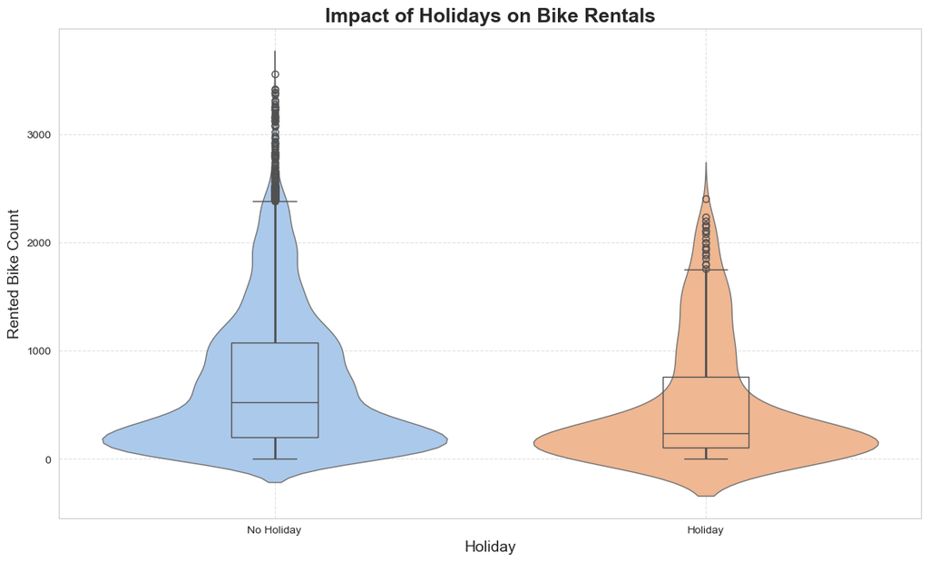

```python
# Set up the figure with a larger size for better visualization
plt.figure(figsize=(14, 8))

# Create a violin plot with box plot overlay to show the distribution and variability
sns.violinplot(
    x='Holiday',
    y='Rented Bike Count',
    data=bike_data,
    palette='pastel',
    inner=None,
    scale='width',
    linewidth=1
)

# Overlay a box plot to highlight median, quartiles, and outliers
sns.boxplot(
    x='Holiday',
    y='Rented Bike Count',
    data=bike_data,
    width=0.2,
    showcaps=True,
    boxprops={'facecolor':'None'},
    showfliers=True,
    whiskerprops={'linewidth':2}
)
plt.title('Impact of Holidays on Bike Rentals', fontsize=18, fontweight='bold')
plt.xlabel('Holiday', fontsize=14)
plt.ylabel('Rented Bike Count', fontsize=14)
plt.grid(True, linestyle='--', alpha=0.6)
plt.show()
```

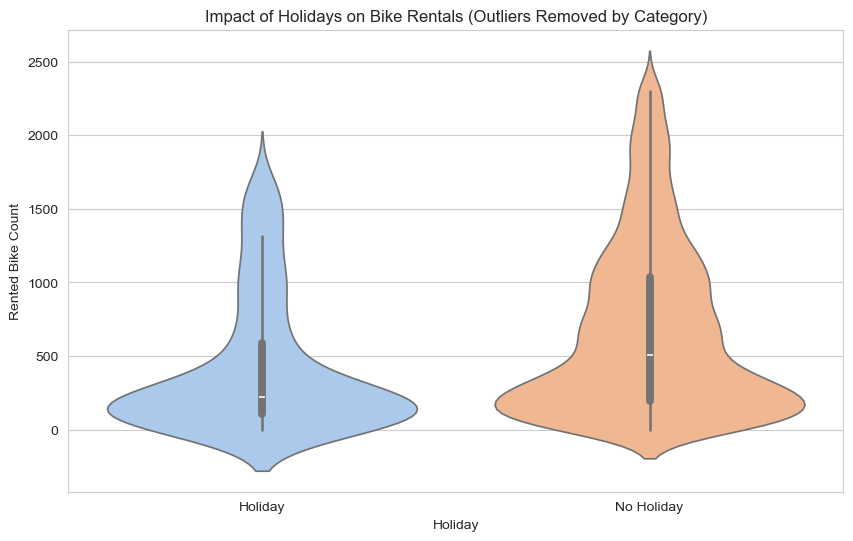

```python
# Define a function to remove outliers within each category
def remove_outliers(df, column, value_column):
    Q1 = df[value_column].quantile(0.25)
    Q3 = df[value_column].quantile(0.75)
    IQR = Q3 - Q1
    lower_bound = Q1 - 1.5 * IQR
    upper_bound = Q3 + 1.5 * IQR
    return df[(df[value_column] >= lower_bound) & (df[value_column] <= upper_bound)]

# Remove outliers separately for each category of 'Holiday'
holiday_data = remove_outliers(bike_data[bike_data['Holiday'] == 'Holiday'], 'Holiday', 'Rented Bike Count')
no_holiday_data = remove_outliers(bike_data[bike_data['Holiday'] == 'No Holiday'], 'Holiday', 'Rented Bike Count')

# Concatenate the cleaned data
filtered_data = pd.concat([holiday_data, no_holiday_data])

# Plotting the cleaned data
plt.figure(figsize=(10, 6))
sns.violinplot(x='Holiday', y='Rented Bike Count', data=filtered_data, palette='pastel', inner='box')
plt.title('Impact of Holidays on Bike Rentals (Outliers Removed by Category)')
plt.xlabel('Holiday')
plt.ylabel('Rented Bike Count')
plt.show()
```

In this plot, the outliers have been removed to provide a clearer comparison of bike rentals between holidays and non-holidays. The distributions now appear more symmetrical and focused, showing that non-holidays still exhibit slightly higher rental counts compared to holidays, but the difference is less pronounced. The spread of the rentals on non-holidays is broader, indicating more variability, while holidays maintain a tighter distribution with lower counts overall. This suggests that after handling outliers, non-holidays still tend to have higher and more varied bike rentals than holidays.

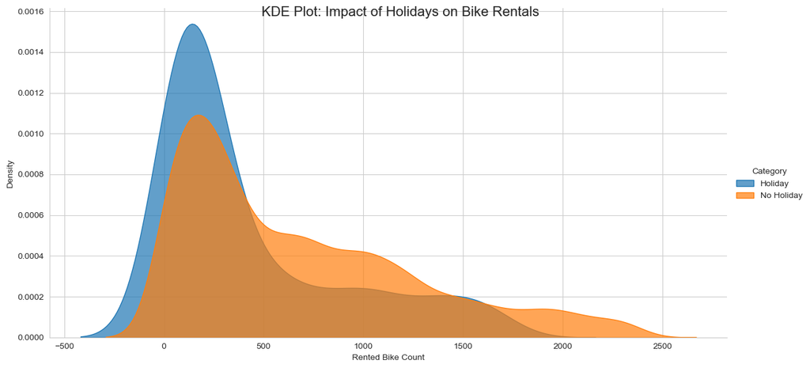

```python
# Prepare the data
holiday_data['Category'] = 'Holiday'
no_holiday_data['Category'] = 'No Holiday'
combined_data = pd.concat([holiday_data, no_holiday_data])

# Plotting the KDE plot with Facet Grid
plt.figure(figsize=(12, 8))
g = sns.FacetGrid(combined_data, hue='Category', height=6, aspect=2)
g.map(sns.kdeplot, 'Rented Bike Count', fill=True, common_norm=False, alpha=0.7)
g.add_legend()
g.set_axis_labels('Rented Bike Count', 'Density')
g.fig.suptitle('KDE Plot: Impact of Holidays on Bike Rentals', fontsize=16)
plt.show()
```

This **KDE plot** shows the distribution of bike rentals on holidays versus non-holidays. The blue area represents rentals on holidays, while the orange area represents non-holidays. The plot indicates that bike rentals are generally lower on holidays compared to non-holidays, as shown by the higher density of rentals near lower counts for holidays. There is a noticeable overlap, but the peak for non-holidays is slightly shifted to the right, suggesting higher rental counts on those days. The spread and tails suggest greater variability in rentals during non-holidays compared to holidays.

**Answer Q2:** These plots confirm that bike rentals are significantly lower on holidays compared to non-holidays, with non-holidays exhibiting more variability and higher peak rentals. This indicates that bike rental demand drops notably during holidays, suggesting that operational strategies could be adjusted accordingly for those days.

# Q3 - INFLUENCE OF FUNCTIONING DAY ON BIKE RENTALS

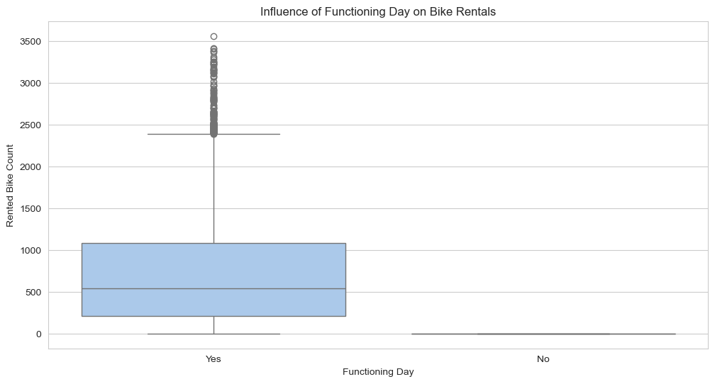

```
                  count        mean         std  min    25%    50%     75%  \
Functioning Day
No                295.0    0.000000    0.000000  0.0    0.0    0.0     0.0
Yes              8465.0  729.156999  642.351166  2.0  214.0  542.0  1084.0

                    max
Functioning Day
No                  0.0
Yes              3556.0
```

```python
# Creating a box plot
plt.figure(figsize=(12, 6))
sns.boxplot(x='Functioning Day', y='Rented Bike Count', data=bike_data, palette='pastel')
plt.title('Influence of Functioning Day on Bike Rentals')
plt.xlabel('Functioning Day')
plt.ylabel('Rented Bike Count')
plt.show()

# Summary statistics for bike rentals on functioning vs. non-functioning days
functioning_day_stats = bike_data.groupby('Functioning Day')['Rented Bike Count'].describe()
print(functioning_day_stats)
```

The **box plot** shows the influence of functioning days on bike rentals. The data reveals that bike rentals only occur on functioning days, with a median rental count around 542 and a maximum of 3,556. On non-functioning days, the rental count is consistently zero across all metrics, indicating that bike rentals do not occur on these days. This difference highlights the critical role of functioning days in bike rental activity, confirming that the service relies entirely on operational status.

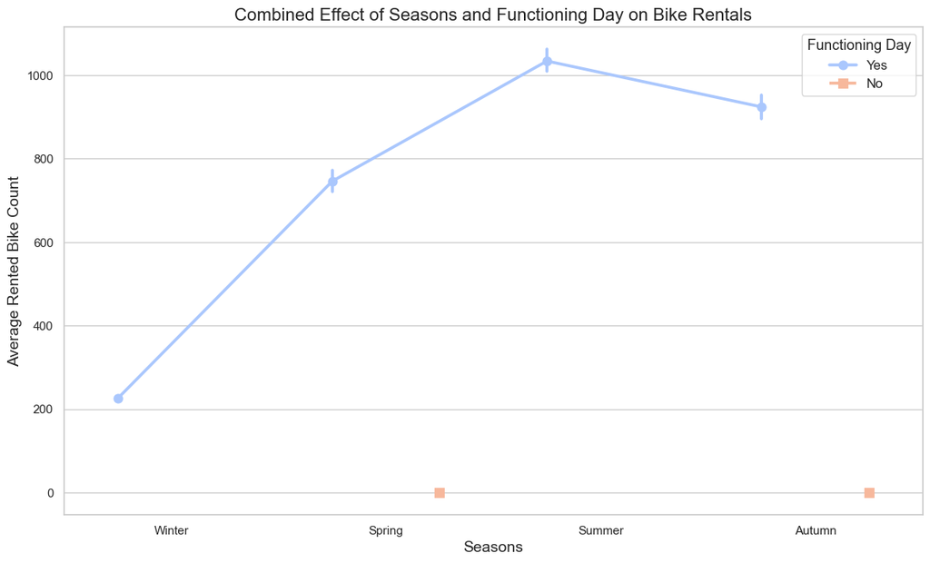

```python
# Set up the figure size and style
plt.figure(figsize=(14, 8))
sns.set(style="whitegrid")

# Create a point plot with dodge to separate the points for different functioning days
sns.pointplot(x='Seasons', y='Rented Bike Count', hue='Functioning Day',
              data=bike_data, palette='coolwarm', dodge=0.5,
              markers=["o", "s"], linestyles=["-", "--"])

plt.title('Combined Effect of Seasons and Functioning Day on Bike Rentals', fontsize=16)
plt.xlabel('Seasons', fontsize=14)
plt.ylabel('Average Rented Bike Count', fontsize=14)
plt.legend(title='Functioning Day', fontsize=12, title_fontsize='13')
plt.show()
```

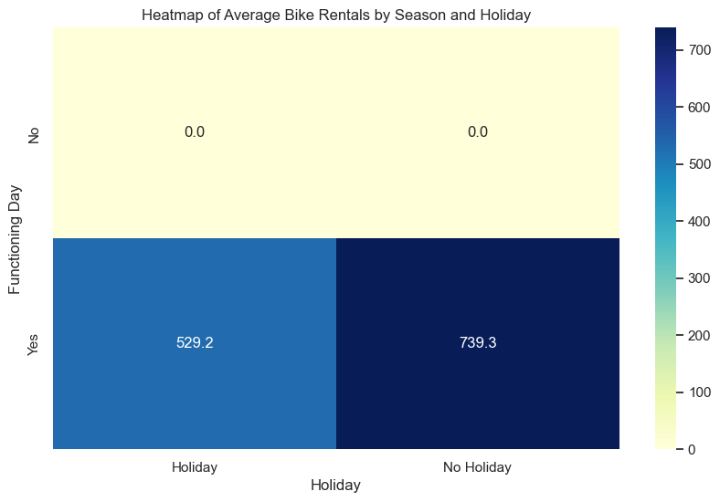

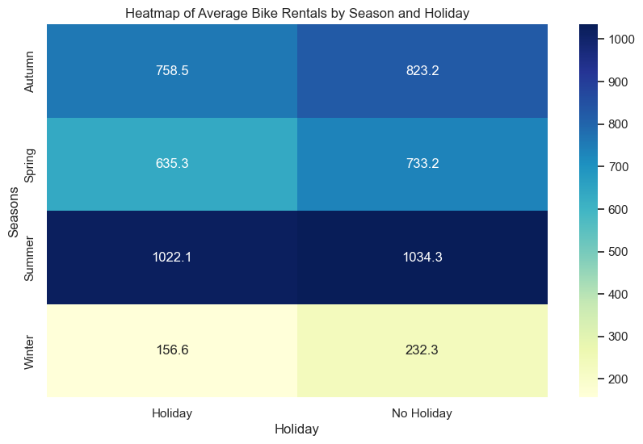

```python
# Cross-tabulation between seasons and holidays
cross_tab = pd.crosstab(bike_data['Functioning Day'], bike_data['Holiday'], values=bike_data['Rented Bike Count'], aggfunc='mean')

# Plot the heatmap
plt.figure(figsize=(10, 6))
sns.heatmap(cross_tab, annot=True, fmt=".1f", cmap="YlGnBu")
plt.title("Heatmap of Average Bike Rentals by Season and Holiday")
plt.ylabel('Functioning Day')
plt.xlabel('Holiday')
plt.show()

#Add further plot to investigate on seasons features
cross_tab = pd.crosstab(bike_data['Seasons'], bike_data['Holiday'], values=bike_data['Rented Bike Count'], aggfunc='mean')

# Plot the heatmap
plt.figure(figsize=(10, 6))
sns.heatmap(cross_tab, annot=True, fmt=".1f", cmap="YlGnBu")
plt.title("Heatmap of Average Bike Rentals by Season and Holiday")
plt.ylabel('Seasons')
plt.xlabel('Holiday')
plt.show()
```

**1° Heatmap** shows that bike rentals are significantly lower on non-functioning days (with counts of 0), regardless of whether it's a holiday or not, which aligns with expectations since no rentals occur when the system is not operating. On functioning days, rentals are higher on non-holidays (average of 739.3) compared to holidays (average of 529.2), indicating that holidays have a dampening effect on bike rentals even when the system is operational.

**Answer Q3:** The analysis reveals that bike rentals occur exclusively on functioning days, with a noticeable decrease during holidays even on these days. This suggests that functioning status is a critical factor for rentals, with holidays further reducing demand when the system is operational.

Here I also explore and analyze numerical features to investigate their distribution, the impact of outliers and their correlation with the target variable, but first a look to some statistical values:

```python
# Descriptive statistics for numerical features
numerical_features = ['Temperature(°C)', 'Humidity(%)', 'Wind speed (m/s)', 'Visibility (10m)', 'Dew point temperature(°C)', 'Solar Radiation (MJ/m2)', 'Rainfall(mm)', 'Snowfall (cm)']
numerical_stats = bike_data[numerical_features].describe()

# Display descriptive statistics
print(numerical_stats)
```

```
       Temperature(°C)  Humidity(%)  Wind speed (m/s)  Visibility (10m)  \
count      8760.000000  8760.000000       8760.000000       8760.000000
mean         12.882922    58.226256          1.724909       1436.825799
std          11.944825    20.362413          1.036300        608.298712
min         -17.800000     0.000000          0.000000         27.000000
25%           3.500000    42.000000          0.900000        940.000000
50%          13.700000    57.000000          1.500000       1698.000000
75%          22.500000    74.000000          2.300000       2000.000000
max          39.400000    98.000000          7.400000       2000.000000

       Dew point temperature(°C)  Solar Radiation (MJ/m2)  Rainfall(mm)  \
count                8760.000000              8760.000000   8760.000000
mean                    4.073813                 0.569111      0.148687
std                    13.060369                 0.868746      1.128193
min                   -30.600000                 0.000000      0.000000
25%                    -4.700000                 0.000000      0.000000
50%                     5.100000                 0.010000      0.000000
75%                    14.800000                 0.930000      0.000000
max                    27.200000                 3.520000     35.000000

       Snowfall (cm)
count    8760.000000
mean        0.075068
std         0.436746
min         0.000000
25%         0.000000
50%         0.000000
75%         0.000000
max         8.800000
```

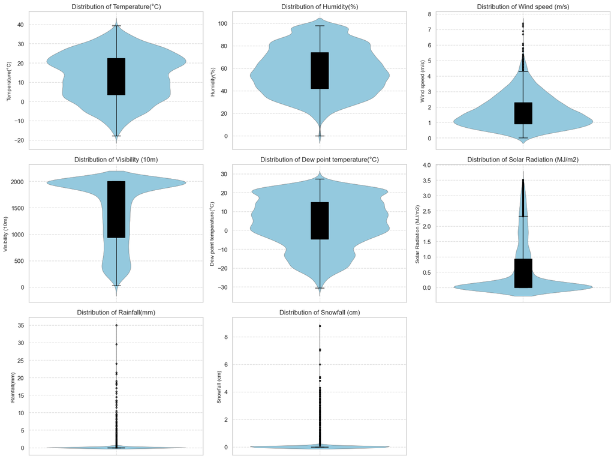

```python
# Creating a Violin plot with boxplot overlay
plt.figure(figsize=(16, 12))
for i, feature in enumerate(numerical_features, 1):
    plt.subplot(3, 3, i)
    sns.violinplot(data=bike_data, y=feature, inner=None, color="skyblue", linewidth=0.5)
    sns.boxplot(data=bike_data, y=feature, width=0.1, color="black", fliersize=2.5)
    plt.title(f'Distribution of {feature}', fontsize=12)
    plt.ylabel(feature, fontsize=10)
    plt.grid(True, linestyle='--', alpha=0.7)
plt.tight_layout()
plt.show()
```

**Explanation of the Box Plot with Violin Plot:**

The violin plots combined with boxplots provide a comprehensive view of the distribution and summary statistics of each numerical feature:

Given the extremely low variation in 'Rainfall (mm)' and 'Snowfall (cm)' (as indicated by the almost flat violin plots), these features may not provide meaningful information for my analysis and model training. For this reason I decided to further investigate whether to keep or drop the Rainfall and Snowfall variables.

```python
# Calculate the correlation of Rainfall and Snowfall with the target variable
correlation_rainfall = bike_data['Rainfall(mm)'].corr(bike_data['Rented Bike Count'])
correlation_snowfall = bike_data['Snowfall (cm)'].corr(bike_data['Rented Bike Count'])

print(f"Correlation between Rainfall and Rented Bike Count: {correlation_rainfall:.4f}")
print(f"Correlation between Snowfall and Rented Bike Count: {correlation_snowfall:.4f}")
```

```
Correlation between Rainfall and Rented Bike Count: -0.1231
Correlation between Snowfall and Rented Bike Count: -0.1418
```

The negative correlations suggest that both 'Rainfall' and 'Snowfall' are inversely related to the number of rented bikes, meaning that as rainfall or snowfall increases, the bike rentals tend to decrease slightly. However, the magnitude of these correlations is relatively low, indicating that neither rainfall nor snowfall has a strong influence on the bike rental counts.

```python
# Prepare the features and target variable
features = bike_data[['Rainfall(mm)', 'Snowfall (cm)']]
target = bike_data['Rented Bike Count']

# Split the data into training and testing sets
X_train, X_test, y_train, y_test = train_test_split(features, target, test_size=0.3, random_state=42)

# Train a simple linear regression model
model = LinearRegression()
model.fit(X_train, y_train)

# Predict on the test set
y_pred = model.predict(X_test)

# Calculate the Mean Squared Error to evaluate the model
mse = mean_squared_error(y_test, y_pred)
print(f"Mean Squared Error of the model with Rainfall and Snowfall: {mse:.4f}")

# Show the coefficients to understand the impact of each feature
coefficients = pd.DataFrame(model.coef_, features.columns, columns=['Coefficient'])
print("\nCoefficients of the Linear Regression Model:")
print(coefficients)
```

```
Mean Squared Error of the model with Rainfall and Snowfall: 397002.7300

Coefficients of the Linear Regression Model:
               Coefficient
Rainfall(mm)    -81.001793
Snowfall (cm)  -199.084760
```

The **MSE value is 397002.7300**, which suggests that the model has a fairly high error when predicting bike rentals based solely on 'Rainfall' and 'Snowfall'. This indicates that these features alone may not be sufficient to create an accurate predictive model.

Given the low correlation, high MSE, and the coefficients' interpretation, I decided to drop both 'Rainfall' and 'Snowfall' from the dataset. These features do not seem to add significant predictive value to the model and may be introducing noise rather than useful information. With this decision I tried to simplify the model and potentially improve its performance by focusing on more impactful features.

```python
bike_data = bike_data.drop(columns=['Rainfall(mm)', 'Snowfall (cm)'])
bike_data.head()
```

|  | Date | Rented Bike Count | Hour | Temperature(°C) | Humidity(%) | Wind speed (m/s) | Visibility (10m) | Dew point temperature(°C) | Solar Radiation (MJ/m2) | Seasons | Holiday | Functioning Day | Year | Month | Day |
| --- | --- | --- | --- | --- | --- | --- | --- | --- | --- | --- | --- | --- | --- | --- | --- |
| 0 | 2017-12-01 | 254 | 0 | -5.2 | 37 | 2.2 | 2000 | -17.6 | 0.0 | Winter | No Holiday | Yes | 2017 | December | 1 |
| 1 | 2017-12-01 | 204 | 1 | -5.5 | 38 | 0.8 | 2000 | -17.6 | 0.0 | Winter | No Holiday | Yes | 2017 | December | 1 |
| 2 | 2017-12-01 | 173 | 2 | -6.0 | 39 | 1.0 | 2000 | -17.7 | 0.0 | Winter | No Holiday | Yes | 2017 | December | 1 |
| 3 | 2017-12-01 | 107 | 3 | -6.2 | 40 | 0.9 | 2000 | -17.6 | 0.0 | Winter | No Holiday | Yes | 2017 | December | 1 |
| 4 | 2017-12-01 | 78 | 4 | -6.0 | 36 | 2.3 | 2000 | -18.6 | 0.0 | Winter | No Holiday | Yes | 2017 | December | 1 |

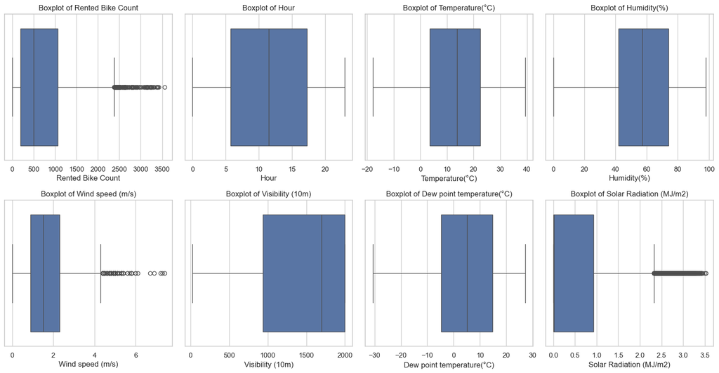

```python
# Update the numerical_features list after dropping columns
numerical_features = bike_data.select_dtypes(include=['float64', 'int64']).columns.tolist()

plt.figure(figsize=(16, 12))
for i, feature in enumerate(numerical_features, 1):
    plt.subplot(3, 4, i)  # Adjust the grid to 3 rows and 4 columns
    sns.boxplot(x=bike_data[feature])
    plt.title(f'Boxplot of {feature}')
plt.tight_layout()
plt.show()
```

The boxplots show the distribution of various numerical features in the dataset, highlighting the spread, central tendency, and presence of outliers. The **'Rented Bike Count'** and **'Solar Radiation'** features exhibit significant outliers, suggesting variability in bike rentals and solar radiation levels. Most other features, such as **'Temperature'**, **'Humidity'**, and **'Dew Point Temperatur'**, show relatively symmetric distributions with few outliers, indicating consistent data. **'Wind Speed'** and **'Solar Radiation'** have noticeable right skewness, indicating a concentration of lower values with some extreme higher values.

```python
# Apply log transformation to reduce skewness
bike_data['Wind speed (m/s)'] = np.log1p(bike_data['Wind speed (m/s)'])
bike_data['Solar Radiation (MJ/m2)'] = np.log1p(bike_data['Solar Radiation (MJ/m2)'])
```

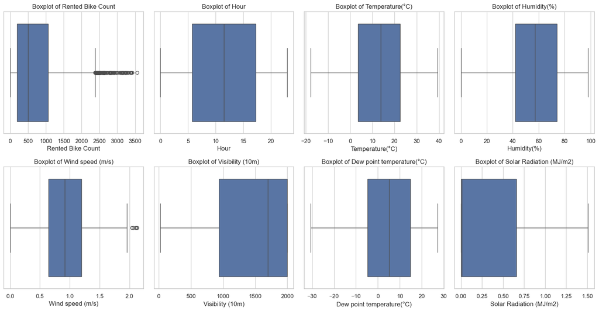

```python
# Run the plot again after log transformation
plt.figure(figsize=(16, 12))
for i, feature in enumerate(numerical_features, 1):
    plt.subplot(3, 4, i)  # Adjust the grid to 3 rows and 4 columns
    sns.boxplot(x=bike_data[feature])
    plt.title(f'Boxplot of {feature}')
plt.tight_layout()
plt.show()
```

After applying the **log transformation** to 'Wind speed (m/s)' and 'Solar Radiation (MJ/m2)', the boxplots reveal a reduction in skewness, with the data now being more symmetrically distributed. This transformation helps to minimize the impact of extreme values, making the features more suitable for modeling by normalizing the distribution. The 'Rented Bike Count' feature still shows some outliers, but as it is my target variable I decided to not handle and to preserve the integrity of the data.

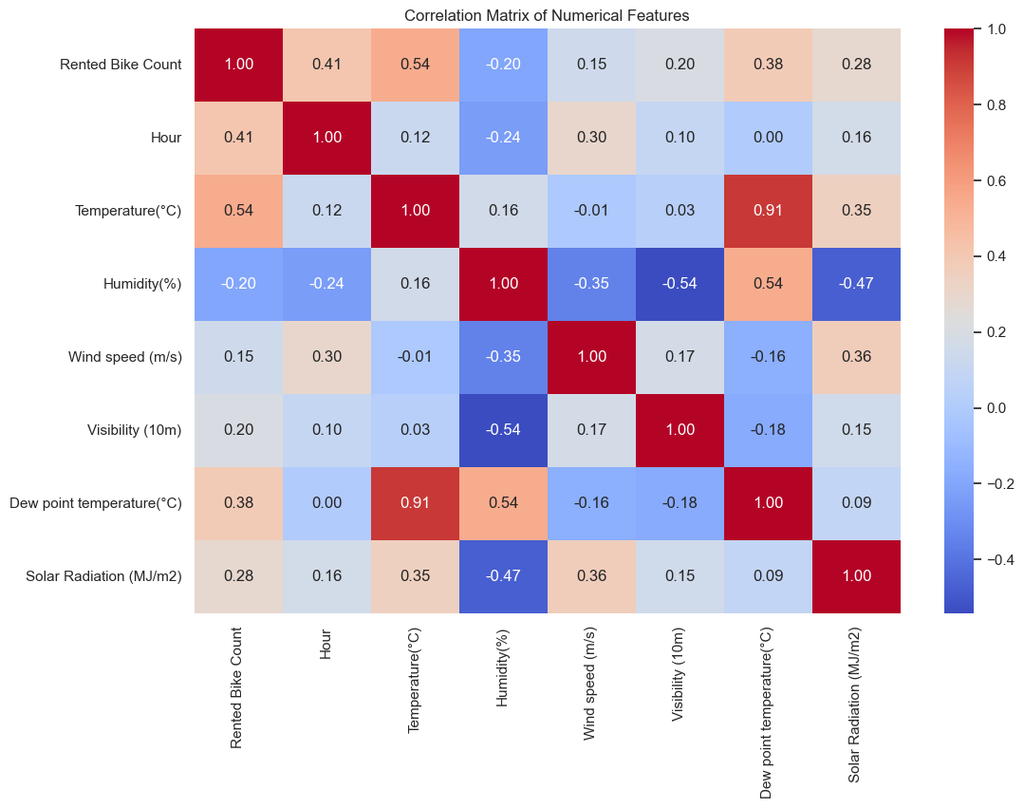

```python
# Correlation matrix for numerical features
corr_matrix = bike_data[numerical_features].corr()

# Plot heatmap of the correlation matrix
plt.figure(figsize=(12, 8))
sns.heatmap(corr_matrix, annot=True, cmap="coolwarm", fmt=".2f")
plt.title('Correlation Matrix of Numerical Features')
plt.show()
```

The **heatmap** illustrates the correlation between all numerical features in the dataset. The most significant positive correlation with Rented Bike Count is observed with **'Temperature(°C)'** (0.54), followed by **'Hour'** (0.41) and **'Dew point temperature(°C)'** (0.38). This suggests that as temperature and dew point increase, so do bike rentals. Conversely, **'Humidity(%)'** shows a negative correlation (-0.20), implying that higher humidity might reduce bike rentals. The correlations provide insights into which factors are most influential in predicting bike rentals, highlighting Temperature(°C) and Hour as critical predictors.

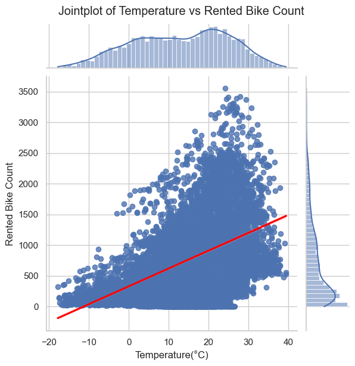

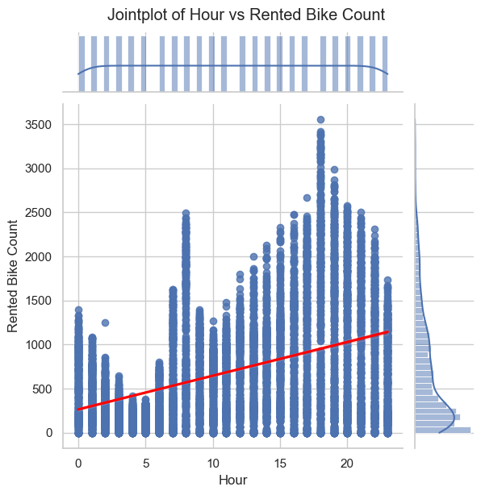

```python
# Jointplot for Temperature and Rented Bike Count
sns.jointplot(x='Temperature(°C)', y='Rented Bike Count', data=bike_data, kind='reg',
              height=6, marginal_kws=dict(bins=50, fill=True), line_kws={'color':'red'})
plt.suptitle('Jointplot of Temperature vs Rented Bike Count', y=1.02)
plt.show()

# Jointplot for Hour and Rented Bike Count
sns.jointplot(x='Hour', y='Rented Bike Count', data=bike_data, kind='reg',
              height=6, marginal_kws=dict(bins=50, fill=True), line_kws={'color':'red'})
plt.suptitle('Jointplot of Hour vs Rented Bike Count', y=1.02)
plt.show()
```

- **Jointplot of Temperature vs Rented Bike Count:**

This plot shows a positive correlation between temperature and the number of rented bikes. As the temperature increases, the bike rentals tend to rise, peaking between 20°C to 30°C. The density plots along the axes indicate a higher concentration of bike rentals at moderate temperatures, suggesting that warmer weather encourages more bike rentals.

- **Jointplot of Hour vs Rented Bike Count:**

This plot illustrates the relationship between the time of day (hour) and bike rentals. There is a clear pattern where bike rentals increase during the morning hours, peak around 17:00 to 18:00 (likely due to commuting), and then decline into the late evening. The linear trend suggests a general increase in rentals throughout the day, followed by a decrease at night.

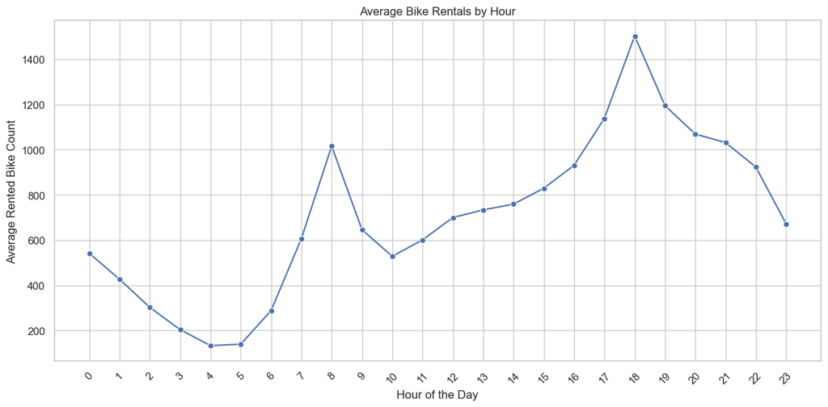

```python
# Grouping by hour to analyze hourly patterns
hourly_rentals = bike_data.groupby('Hour')['Rented Bike Count'].mean().reset_index()

# Creating a line plot
plt.figure(figsize=(12, 6))
sns.lineplot(x='Hour', y='Rented Bike Count', data=hourly_rentals, marker='o')
plt.title('Average Bike Rentals by Hour')
plt.xlabel('Hour of the Day')
plt.ylabel('Average Rented Bike Count')
plt.xticks(range(0, 24), rotation=45)
plt.grid(True)
plt.tight_layout()
plt.show()
```

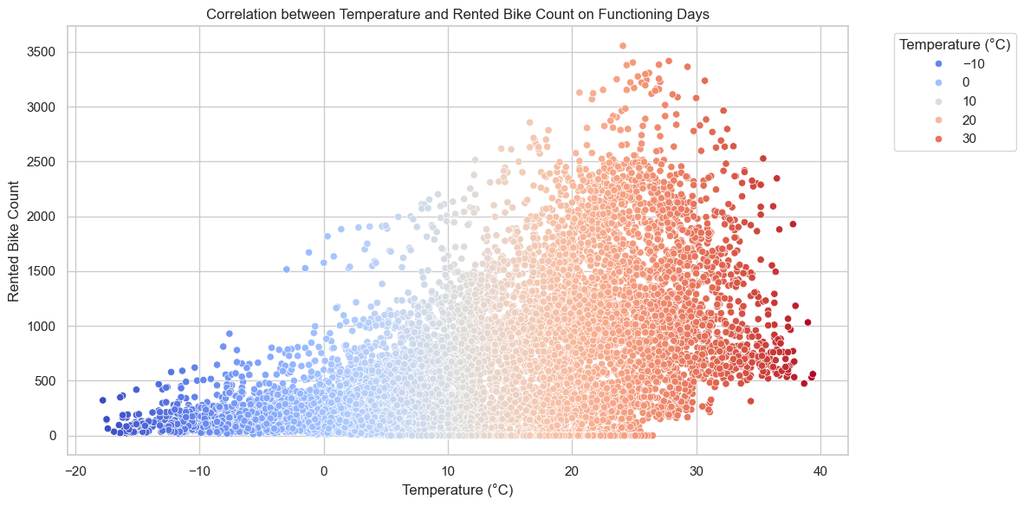

```python
# Creating a scatter plot to correlate 'Temperature (°C)' and 'Functioning Day' with the target
plt.figure(figsize=(12, 6))
sns.scatterplot(
    x='Temperature(°C)',
    y='Rented Bike Count',
    data=bike_data,
    hue='Temperature(°C)',
    palette='coolwarm'
)
plt.title('Correlation between Temperature and Rented Bike Count on Functioning Days')
plt.xlabel('Temperature (°C)')
plt.ylabel('Rented Bike Count')
plt.legend(title='Temperature (°C)', bbox_to_anchor=(1.05, 1), loc='upper left')
plt.tight_layout()
plt.show()
```

This **scatter plot** illustrates the positive correlation between 'Temperature (°C)' and 'Rented Bike Count' on functioning days, indicating that bike rentals tend to increase as the temperature rises. The hue gradient reflects temperature values, with warmer colors showing higher temperatures associated with higher rental counts. This pattern suggests that warmer weather encourages more bike usage, highlighting temperature as a significant predictor for rental demand.

```python
# Creating a 3D plot
fig = px.scatter_3d(
    bike_data,
    x='Temperature(°C)',
    y='Hour',
    z='Rented Bike Count',
    color='Rented Bike Count',
    color_continuous_scale='RdBu',
    labels={'Temperature(°C)': 'Temperature (°C)', 'Hour': 'Hour of the Day', 'Rented Bike Count': 'Rented Bike Count'},
)

# Update layout for better visualization
fig.update_layout(
    title='Interactive 3D Scatter Plot: Temperature, Hour, and Bike Rentals',
    scene=dict(
        xaxis=dict(title='Temperature (°C)'),
        yaxis=dict(title='Hour'),
        zaxis=dict(title='Rented Bike Count'),
    ),
    coloraxis_colorbar=dict(
        title="Rented Bike Count"
    )
)
fig.show()
```

[interactive chart not shown]

The **3D plot** displays the interaction between 'Temperature(°C)', 'Hour', and 'Rented Bike Count'. It reveals that bike rentals tend to increase during specific temperature ranges and times of the day. The color gradient highlights that the highest number of bike rentals occurs during moderate temperatures (around 20-30°C) and peak commuting hours (around 8-9 AM and 5-6 PM), suggesting that both temperature and time significantly influence bike rental behavior.

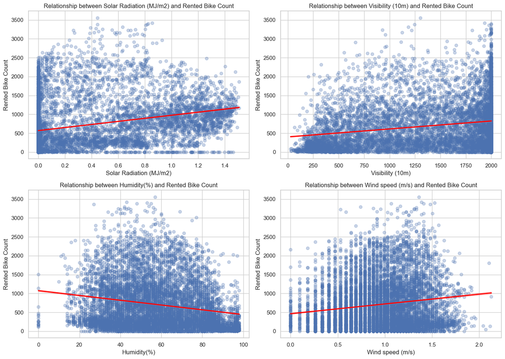

```python
# Define the features and target variable
features = ['Solar Radiation (MJ/m2)', 'Visibility (10m)', 'Humidity(%)', 'Wind speed (m/s)']
target = 'Rented Bike Count'

# Set the plot style
sns.set(style="whitegrid")

# Create a 2x2 grid of scatter plots with regression lines
plt.figure(figsize=(14, 10))

for i, feature in enumerate(features):
    plt.subplot(2, 2, i + 1)
    sns.regplot(x=bike_data[feature], y=bike_data[target], scatter_kws={'alpha':0.3}, line_kws={'color': 'red'})
    plt.title(f'Relationship between {feature} and {target}')
    plt.xlabel(feature)
    plt.ylabel(target)

plt.tight_layout()
plt.show()
```

- **Solar Radiation vs. Rented Bike Count:**

The scatter plot shows a weak positive correlation between Solar Radiation and the Rented Bike Count, as indicated by the slightly upward-sloping red regression line. This suggests that higher solar radiation tends to be associated with a slight increase in bike rentals. However, the spread of data points indicates a high variance, implying that other factors also significantly influence the rental count.

- **Visibility vs. Rented Bike Count**

The plot reveals a very weak positive relationship between Visibility and the Rented Bike Count. The regression line slopes slightly upwards, indicating a minor increase in bike rentals with better visibility. The wide scatter of points implies that visibility alone does not strongly predict bike rentals, with other variables likely playing a larger role.

- **Humidity vs. Rented Bike Count:**

This scatter plot shows a weak negative correlation between Humidity and the Rented Bike Count, as the regression line slopes slightly downwards. Higher humidity levels are generally associated with a slight decrease in bike rentals. The distribution of data points is broad, suggesting that humidity is not a strong predictor of bike rental activity.

- **Wind Speed vs. Rented Bike Count:**

The plot indicates a weak positive correlation between Wind Speed and the Rented Bike Count, with the regression line showing a slight upward trend. Higher wind speeds are marginally associated with an increase in bike rentals, though the relationship is not strong. The high spread and clustering of data points around certain wind speeds suggest limited predictive power of wind speed on bike rentals.

```python
# Calculate VIF for each numerical feature
X = bike_data[numerical_features]
vif_data = pd.DataFrame()
vif_data["Feature"] = X.columns
vif_data["VIF"] = [variance_inflation_factor(X.values, i) for i in range(len(X.columns))]

# Display VIF
print(vif_data.sort_values(by="VIF", ascending=False))
```

```
                     Feature        VIF
2            Temperature(°C)  37.123249
6  Dew point temperature(°C)  18.485897
4           Wind speed (m/s)   9.357829
5           Visibility (10m)   9.065963
3                Humidity(%)   6.365274
1                       Hour   5.007762
0          Rented Bike Count   4.019486
7    Solar Radiation (MJ/m2)   3.148436
```

The VIF calculation helps identify multicollinearity among the numerical features. High VIF values indicate that a feature is strongly correlated with other features, which can distort the results of regression models. The output shows that 'Temperature(°C)' and 'Dew point temperature(°C)' have very high VIF values, suggesting that these variables are closely related to others in the dataset. This may indicate potential redundancy, meaning that one of these features might be removed to simplify the model without losing significant information.

Given the high VIF values for both 'Temperature(°C)' and 'Dew point temperature(°C)', I decided to drop one of them to address multicollinearity.

I considered dropping 'Dew point temperature(°C)' because 'Temperature(°C)' is likely more directly related to bike rental behavior (as indicated by the higher correlation with Rented Bike Count in previous analyses). By keeping 'Temperature(°C)' and removing 'Dew point temperature(°C)', I retain the most critical variable while trying to reduce multicollinearity.

```python
# Drop 'Dew point temperature(°C)' and 'Date' columns
bike_data = bike_data.drop(columns=['Dew point temperature(°C)', 'Date'])

# Verify the change
bike_data.head()
```

|  | Rented Bike Count | Hour | Temperature(°C) | Humidity(%) | Wind speed (m/s) | Visibility (10m) | Solar Radiation (MJ/m2) | Seasons | Holiday | Functioning Day | Year | Month | Day |
| --- | --- | --- | --- | --- | --- | --- | --- | --- | --- | --- | --- | --- | --- |
| 0 | 254 | 0 | -5.2 | 37 | 1.163151 | 2000 | 0.0 | Winter | No Holiday | Yes | 2017 | December | 1 |
| 1 | 204 | 1 | -5.5 | 38 | 0.587787 | 2000 | 0.0 | Winter | No Holiday | Yes | 2017 | December | 1 |
| 2 | 173 | 2 | -6.0 | 39 | 0.693147 | 2000 | 0.0 | Winter | No Holiday | Yes | 2017 | December | 1 |
| 3 | 107 | 3 | -6.2 | 40 | 0.641854 | 2000 | 0.0 | Winter | No Holiday | Yes | 2017 | December | 1 |
| 4 | 78 | 4 | -6.0 | 36 | 1.193922 | 2000 | 0.0 | Winter | No Holiday | Yes | 2017 | December | 1 |

**In conclusion**, I removed the following features:

- **Dew Point Temperature (°C)**
- **Date**

Removed due to its high correlation with 'Temperature (°C)', which led to multicollinearity issues. Since Temperature (°C) was more significant, 'Dew Point Temperature' was deemed redundant. 'Date' because I extracted each part of the date to have single variables.

- **Snowfall (cm)**
- **Rainfall (mm)**

Both 'Snowfall' and 'Rainfall' were removed because they showed minimal variability and had no significant correlation with the target variable, 'Rented Bike Count'. Their lack of impact on the model and overall analysis justified their removal. These adjustments helped refine the dataset, reduce redundancy, and focus on the most impactful variables, improving the model's performance and interpretability.

I handled the following features:

- **Wind speed (m/s)**
- **Solar Radiation (MJ/m2)**

By handling outliers with a log transformation with the aim of reducing skewness.

# DATA PRE-PROCESSING AND FEATURE ENGINEERING

Here I standardized the numerical features using StandardScaler to ensure that each feature has a mean of 0 and a standard deviation of 1. This process is crucial for algorithms sensitive to the scale of data, such as linear regression or neural networks, as it improves model performance and convergence speed. Standardization also ensures that all features contribute equally to the model, preventing any single feature from dominating due to it s scale.

```python
# Selecting StandardScaler to standardize the numerical features
scaler = StandardScaler()

# List of numerical features
numerical_features = [
    'Temperature(°C)', 'Humidity(%)', 'Wind speed (m/s)',
    'Visibility (10m)', 'Solar Radiation (MJ/m2)',
]

# Fit and transform the numerical features
bike_data[numerical_features] = scaler.fit_transform(bike_data[numerical_features])

# Verify the changes
bike_data.head()
```

|  | Rented Bike Count | Hour | Temperature(°C) | Humidity(%) | Wind speed (m/s) | Visibility (10m) | Solar Radiation (MJ/m2) | Seasons | Holiday | Functioning Day | Year | Month | Day |
| --- | --- | --- | --- | --- | --- | --- | --- | --- | --- | --- | --- | --- | --- |
| 0 | 254 | 0 | -1.513957 | -1.042483 | 0.616347 | 0.925871 | -0.737679 | Winter | No Holiday | Yes | 2017 | December | 1 |
| 1 | 204 | 1 | -1.539074 | -0.993370 | -0.924040 | 0.925871 | -0.737679 | Winter | No Holiday | Yes | 2017 | December | 1 |
| 2 | 173 | 2 | -1.580936 | -0.944257 | -0.641965 | 0.925871 | -0.737679 | Winter | No Holiday | Yes | 2017 | December | 1 |
| 3 | 107 | 3 | -1.597680 | -0.895144 | -0.779289 | 0.925871 | -0.737679 | Winter | No Holiday | Yes | 2017 | December | 1 |
| 4 | 78 | 4 | -1.580936 | -1.091596 | 0.698730 | 0.925871 | -0.737679 | Winter | No Holiday | Yes | 2017 | December | 1 |

```python
# One-Hot Encoding for Nominal Features
bike_data = pd.get_dummies(bike_data, columns=['Seasons', 'Holiday', 'Functioning Day'], drop_first=False)

# Rename the columns
bike_data.rename(columns={
    'Holiday_Holiday': 'Holiday YES',
    'Holiday_No Holiday': 'Holiday NO',
    'Functioning Day_Yes': 'Functioning Day YES',
    'Functioning Day_No': 'Functioning Day NO',
    'Seasons_Winter': 'Winter',
    'Seasons_Autumn': 'Autumn',
    'Seasons_Summer': 'Summer',
    'Seasons_Spring': 'Spring'
}, inplace=True)

# Convert boolean columns (True/False) to integers (1/0) if any remain
# This step should catch any remaining True/False values and convert them to 1/0
for col in bike_data.select_dtypes(include=['bool']).columns:
    bike_data[col] = bike_data[col].astype(int)

# Convert month names to numeric values
month_mapping = {
    'January': 1, 'February': 2, 'March': 3, 'April': 4,
    'May': 5, 'June': 6, 'July': 7, 'August': 8,
    'September': 9, 'October': 10, 'November': 11, 'December': 12
}
bike_data['Month'] = bike_data['Month'].map(month_mapping)

# Verify the changes
bike_data.head()
```

|  | Rented Bike Count | Hour | Temperature(°C) | Humidity(%) | Wind speed (m/s) | Visibility (10m) | Solar Radiation (MJ/m2) | Year | Month | Day | Autumn | Spring | Summer | Winter | Holiday YES | Holiday NO | Functioning Day NO | Functioning Day YES |
| --- | --- | --- | --- | --- | --- | --- | --- | --- | --- | --- | --- | --- | --- | --- | --- | --- | --- | --- |
| 0 | 254 | 0 | -1.513957 | -1.042483 | 0.616347 | 0.925871 | -0.737679 | 2017 | 12 | 1 | 0 | 0 | 0 | 1 | 0 | 1 | 0 | 1 |
| 1 | 204 | 1 | -1.539074 | -0.993370 | -0.924040 | 0.925871 | -0.737679 | 2017 | 12 | 1 | 0 | 0 | 0 | 1 | 0 | 1 | 0 | 1 |
| 2 | 173 | 2 | -1.580936 | -0.944257 | -0.641965 | 0.925871 | -0.737679 | 2017 | 12 | 1 | 0 | 0 | 0 | 1 | 0 | 1 | 0 | 1 |
| 3 | 107 | 3 | -1.597680 | -0.895144 | -0.779289 | 0.925871 | -0.737679 | 2017 | 12 | 1 | 0 | 0 | 0 | 1 | 0 | 1 | 0 | 1 |
| 4 | 78 | 4 | -1.580936 | -1.091596 | 0.698730 | 0.925871 | -0.737679 | 2017 | 12 | 1 | 0 | 0 | 0 | 1 | 0 | 1 | 0 | 1 |

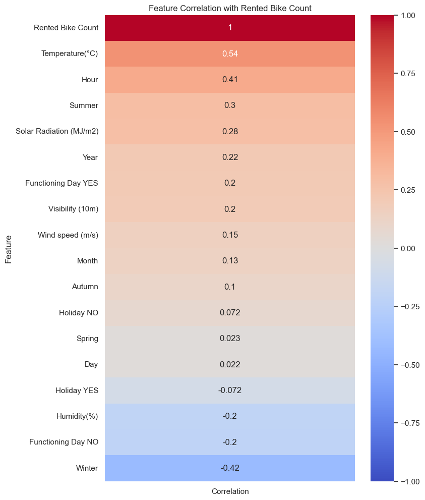

```python
# Compute the correlation matrix
corr_matrix = bike_data.corr()

# Sort the correlation values with respect to the target variable
target_corr = corr_matrix["Rented Bike Count"].sort_values(ascending=False)

# Create a DataFrame to visualize only the sorted correlations with the target
target_corr_df = target_corr.reset_index().rename(columns={"index": "Feature", "Rented Bike Count": "Correlation"})

# Plotting the heatmap
plt.figure(figsize=(8, 12))
sns.heatmap(target_corr_df.set_index("Feature"), annot=True, cmap="coolwarm", center=0, vmin=-1, vmax=1)
plt.title("Feature Correlation with Rented Bike Count")
plt.show()
```

This **heatmap** is focused solely on the correlation of each feature with the target variable 'Rented Bike Count'. It reaffirms that 'Temperature(°C)' has the strongest correlation with bike rentals (0.54), indicating that warmer weather encourages more bike rentals. The 'Hour' variable also shows a strong positive correlation (0.41), suggesting that the time of day significantly affects rental counts. The negative correlation with 'Humidity(%)' (-0.20) is confirmed and emphasizes that increased humidity tends to decrease bike rentals.

```python
# Calculate total rentals per month (sum of all daily counts within the same month)
monthly_totals = bike_data.groupby(['Year', 'Month'])['Rented Bike Count'].sum().reset_index()
monthly_totals.rename(columns={'Rented Bike Count': 'Total Rentals Month'}, inplace=True)

# Merge the total monthly rentals back to the original data
bike_data = pd.merge(bike_data, monthly_totals, on=['Year', 'Month'], how='left')

# Verify the changes
bike_data.head()
```

|  | Rented Bike Count | Hour | Temperature(°C) | Humidity(%) | Wind speed (m/s) | Visibility (10m) | Solar Radiation (MJ/m2) | Year | Month | Day | Autumn | Spring | Summer | Winter | Holiday YES | Holiday NO | Functioning Day NO | Functioning Day YES | Total Rentals Month |
| --- | --- | --- | --- | --- | --- | --- | --- | --- | --- | --- | --- | --- | --- | --- | --- | --- | --- | --- | --- |
| 0 | 254 | 0 | -1.513957 | -1.042483 | 0.616347 | 0.925871 | -0.737679 | 2017 | 12 | 1 | 0 | 0 | 0 | 1 | 0 | 1 | 0 | 1 | 185330 |
| 1 | 204 | 1 | -1.539074 | -0.993370 | -0.924040 | 0.925871 | -0.737679 | 2017 | 12 | 1 | 0 | 0 | 0 | 1 | 0 | 1 | 0 | 1 | 185330 |
| 2 | 173 | 2 | -1.580936 | -0.944257 | -0.641965 | 0.925871 | -0.737679 | 2017 | 12 | 1 | 0 | 0 | 0 | 1 | 0 | 1 | 0 | 1 | 185330 |
| 3 | 107 | 3 | -1.597680 | -0.895144 | -0.779289 | 0.925871 | -0.737679 | 2017 | 12 | 1 | 0 | 0 | 0 | 1 | 0 | 1 | 0 | 1 | 185330 |
| 4 | 78 | 4 | -1.580936 | -1.091596 | 0.698730 | 0.925871 | -0.737679 | 2017 | 12 | 1 | 0 | 0 | 0 | 1 | 0 | 1 | 0 | 1 | 185330 |

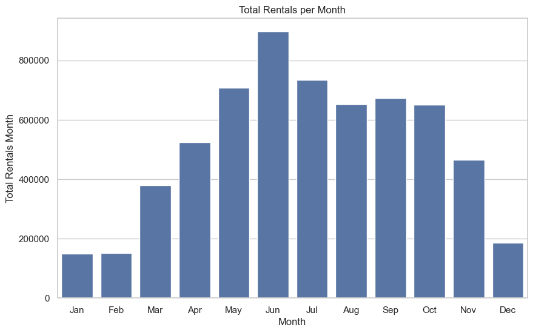

```python
# Bar plot to visualize Total Rentals per Month
plt.figure(figsize=(10, 6))
sns.barplot(x='Month', y='Total Rentals Month', data=bike_data.drop_duplicates(['Year', 'Month']))
plt.title('Total Rentals per Month')
plt.xlabel('Month')
plt.ylabel('Total Rentals Month')
plt.xticks(ticks=range(12), labels=['Jan', 'Feb', 'Mar', 'Apr', 'May', 'Jun', 'Jul', 'Aug', 'Sep', 'Oct', 'Nov', 'Dec'])
plt.show()
```

The **bar plot** shows a distinct seasonality in bike rentals, with the highest numbers seen in the summer months (June, July, and August) and a marked decline during the winter months (December, January, and February). This pattern suggests a strong correlation between bike rental activity and seasonal weather variations, where warmer temperatures and longer daylight hours encourage more bike usage. Spring months like April and May also see a steady rise in rentals as conditions improve, while the gradual decrease from September to November aligns with cooler temperatures and shorter days. This trend underscores the importance of considering seasonality when analyzing and forecasting bike rental demand.

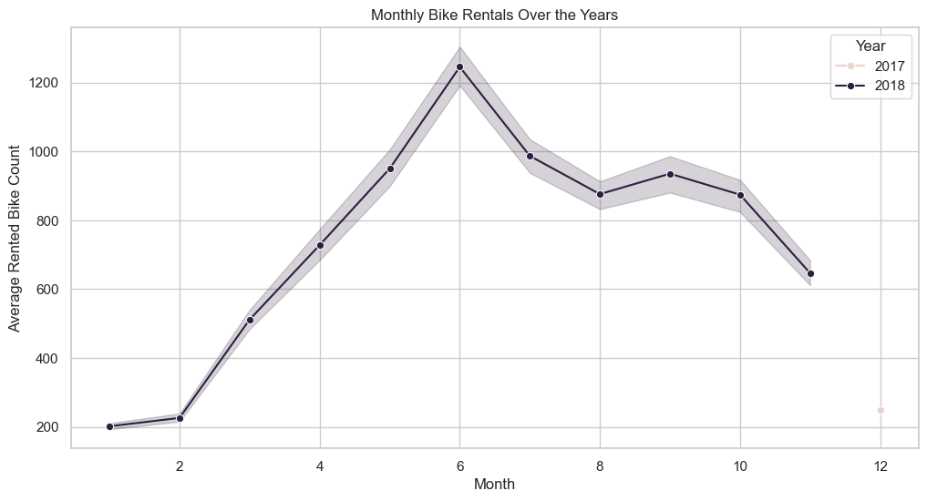

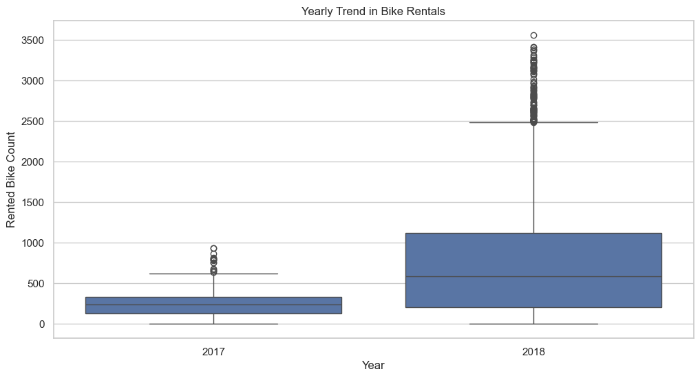

```python
# Monthly Trends in Bike Rentals
plt.figure(figsize=(12, 6))
sns.lineplot(x='Month', y='Rented Bike Count', hue='Year', data=bike_data, marker='o')
plt.title('Monthly Bike Rentals Over the Years')
plt.xlabel('Month')
plt.ylabel('Average Rented Bike Count')
plt.show()

# Yearly Trend in Bike Rentals
plt.figure(figsize=(12, 6))
sns.boxplot(x='Year', y='Rented Bike Count', data=bike_data)
plt.title('Yearly Trend in Bike Rentals')
plt.xlabel('Year')
plt.ylabel('Rented Bike Count')
plt.show()
```

The **box plot**, Yearly Trend in Bike Rentals, highlights a significant increase in bike rentals from 2017 to 2018. Given that the 2017 data only includes December, the lower rentals reflect a winter effect, while the 2018 data, covering almost the entire year, shows higher variability and median values. The box plot for 2018 indicates a broader range of rental counts with more outliers, especially in peak seasons, capturing the full spectrum of seasonal variability.

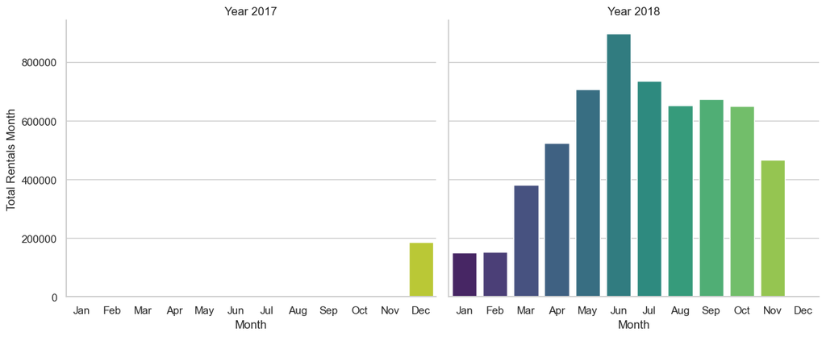

```python
# Set up the FacetGrid with separate subplots for each year
g = sns.FacetGrid(bike_data.drop_duplicates(['Year', 'Month']), col="Year", height=5, aspect=1.2)

# Define the correct order of months
month_order = list(range(1, 13))

# Map a bar plot to the grid with the correct order of months
g.map(sns.barplot, "Month", "Total Rentals Month", order=month_order, palette="viridis")

# Customize the plot
g.set_axis_labels("Month", "Total Rentals Month")
g.set_titles("Year {col_name}")
g.set(xticks=range(12), xticklabels=['Jan', 'Feb', 'Mar', 'Apr', 'May', 'Jun', 'Jul', 'Aug', 'Sep', 'Oct', 'Nov', 'Dec'])

plt.show()
```

Then I decided to create some new features using the expanding method, which provides a cumulative calculation over time:

- **Expanding Average Temperature:** This feature calculates the cumulative mean of the temperature up to the current observation. It helps in understanding how the average temperature has changed over time.
- **Expanding Total Rentals:** This feature calculates the cumulative sum of rented bike counts up to the current observation, indicating the total number of bikes rented over time.
- **Expanding Average Rentals:** This feature calculates the cumulative mean of bike rentals up to the current observation, showing the average rentals over time.

With these features I aim to better track trends over time and understand how the temperature and rentals have evolved during the period observed.

```python
# Calculate the expanding average for temperature over time
bike_data['Expanding Avg Temperature'] = bike_data['Temperature(°C)'].expanding().mean()

# Calculate the expanding total rentals over time
bike_data['Expanding Total Rentals'] = bike_data['Rented Bike Count'].expanding().sum()

# Calculate the expanding average for rentals over time
bike_data['Expanding Avg Rentals'] = bike_data['Rented Bike Count'].expanding().mean()

# Check the first 30 rows to verify the results
bike_data[['Temperature(°C)', 'Rented Bike Count', 'Expanding Avg Temperature', 'Expanding Total Rentals', 'Expanding Avg Rentals']].head(30
)
```

|  | Temperature(°C) | Rented Bike Count | Expanding Avg Temperature | Expanding Total Rentals | Expanding Avg Rentals |
| --- | --- | --- | --- | --- | --- |
| 0 | -1.513957 | 254 | -1.513957 | 254.0 | 254.000000 |
| 1 | -1.539074 | 204 | -1.526516 | 458.0 | 229.000000 |
| 2 | -1.580936 | 173 | -1.544656 | 631.0 | 210.333333 |
| 3 | -1.597680 | 107 | -1.557912 | 738.0 | 184.500000 |
| 4 | -1.580936 | 78 | -1.562517 | 816.0 | 163.200000 |
| 5 | -1.614425 | 100 | -1.571168 | 916.0 | 152.666667 |
| 6 | -1.631169 | 181 | -1.579740 | 1097.0 | 156.714286 |
| 7 | -1.698148 | 460 | -1.594541 | 1557.0 | 194.625000 |
| 8 | -1.714893 | 930 | -1.607913 | 2487.0 | 276.333333 |
| 9 | -1.622797 | 490 | -1.609402 | 2977.0 | 297.700000 |
| 10 | -1.371628 | 339 | -1.587786 | 3316.0 | 301.454545 |
| 11 | -1.120459 | 360 | -1.548842 | 3676.0 | 306.333333 |
| 12 | -0.936268 | 449 | -1.501721 | 4125.0 | 317.307692 |
| 13 | -0.877662 | 451 | -1.457145 | 4576.0 | 326.857143 |
| 14 | -0.827428 | 447 | -1.415164 | 5023.0 | 334.866667 |
| 15 | -0.902779 | 463 | -1.383140 | 5486.0 | 342.875000 |
| 16 | -0.978130 | 484 | -1.359316 | 5970.0 | 351.176471 |
| 17 | -1.011619 | 555 | -1.339999 | 6525.0 | 362.500000 |
| 18 | -1.028364 | 862 | -1.323597 | 7387.0 | 388.789474 |
| 19 | -1.078597 | 600 | -1.311347 | 7987.0 | 399.350000 |
| 20 | -1.103714 | 426 | -1.301460 | 8413.0 | 400.619048 |
| 21 | -1.145576 | 405 | -1.294375 | 8818.0 | 400.818182 |
| 22 | -1.153948 | 398 | -1.288269 | 9216.0 | 400.695652 |
| 23 | -1.187437 | 323 | -1.284068 | 9539.0 | 397.458333 |
| 24 | -1.229299 | 328 | -1.281877 | 9867.0 | 394.680000 |
| 25 | -1.262788 | 308 | -1.281143 | 10175.0 | 391.346154 |
| 26 | -1.321394 | 262 | -1.282634 | 10437.0 | 386.555556 |
| 27 | -1.371628 | 167 | -1.285812 | 10604.0 | 378.714286 |
| 28 | -1.396745 | 89 | -1.289637 | 10693.0 | 368.724138 |
| 29 | -1.413490 | 79 | -1.293766 | 10772.0 | 359.066667 |

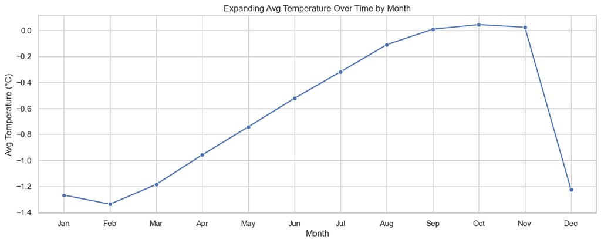

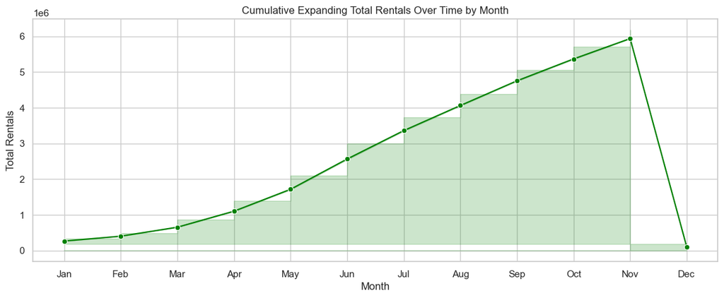

```python
# Plot Expanding Avg Temperature Over Time by Month
plt.figure(figsize=(14, 5))
sns.lineplot(data=bike_data, x='Month', y='Expanding Avg Temperature', marker='o')
plt.title('Expanding Avg Temperature Over Time by Month')
plt.xlabel('Month')
plt.ylabel('Avg Temperature (°C)')
plt.xticks(ticks=range(1, 13), labels=['Jan', 'Feb', 'Mar', 'Apr', 'May', 'Jun', 'Jul', 'Aug', 'Sep', 'Oct', 'Nov', 'Dec'])
plt.grid(True)
plt.show()

# Plot Cumulative Expanding Total Rentals Over Time by Month
plt.figure(figsize=(14, 5))
sns.lineplot(data=bike_data, x='Month', y='Expanding Total Rentals', marker='o', color='green')
plt.title('Cumulative Expanding Total Rentals Over Time by Month')
plt.xlabel('Month')
plt.ylabel('Total Rentals')
plt.xticks(ticks=range(1, 13), labels=['Jan', 'Feb', 'Mar', 'Apr', 'May', 'Jun', 'Jul', 'Aug', 'Sep', 'Oct', 'Nov', 'Dec'])
plt.grid(True)
plt.fill_between(bike_data['Month'], bike_data['Expanding Total Rentals'], color='green', alpha=0.2)
plt.show()
```

After this I decided also to calculate rolling averages for both temperature and bike rentals over a 7-day window:

- **Avg Temperature 7days:** This feature calculates the rolling mean of the temperature over the previous 7 days. It smoothens the temperature values to show trends over a week, reducing the noise from daily fluctuations.
- **Avg Rentals 7days:** Similarly, this feature calculates the rolling mean of rented bike counts over the past 7 days, providing a smoother view of rental trends week by week.

With these rolling averages I hope to capturing short-term trends and patterns, helping to reduce the impact of daily variability and highlight more consistent trends in the data.

```python
# Calculate the average rentals over 7 days range
bike_data['Avg Temperature 7days'] = bike_data['Temperature(°C)'].rolling(window=7, min_periods=1).mean()

# Calculate the average temperature over 7 days range
bike_data['Avg Rentals 7days'] = bike_data['Rented Bike Count'].rolling(window=7, min_periods=1).mean()

# Check the first 30 rows to verify the results
bike_data[['Temperature(°C)', 'Rented Bike Count', 'Avg Rentals 7days', 'Avg Temperature 7days']].head(30)
```

|  | Temperature(°C) | Rented Bike Count | Avg Rentals 7days | Avg Temperature 7days |
| --- | --- | --- | --- | --- |
| 0 | -1.513957 | 254 | 254.000000 | -1.513957 |
| 1 | -1.539074 | 204 | 229.000000 | -1.526516 |
| 2 | -1.580936 | 173 | 210.333333 | -1.544656 |
| 3 | -1.597680 | 107 | 184.500000 | -1.557912 |
| 4 | -1.580936 | 78 | 163.200000 | -1.562517 |
| 5 | -1.614425 | 100 | 152.666667 | -1.571168 |
| 6 | -1.631169 | 181 | 156.714286 | -1.579740 |
| 7 | -1.698148 | 460 | 186.142857 | -1.606053 |
| 8 | -1.714893 | 930 | 289.857143 | -1.631169 |
| 9 | -1.622797 | 490 | 335.142857 | -1.637150 |
| 10 | -1.371628 | 339 | 368.285714 | -1.604857 |
| 11 | -1.120459 | 360 | 408.571429 | -1.539074 |
| 12 | -0.936268 | 449 | 458.428571 | -1.442195 |
| 13 | -0.877662 | 451 | 497.000000 | -1.334551 |
| 14 | -0.827428 | 447 | 495.142857 | -1.210162 |
| 15 | -0.902779 | 463 | 428.428571 | -1.094146 |
| 16 | -0.978130 | 484 | 427.571429 | -1.002051 |
| 17 | -1.011619 | 555 | 458.428571 | -0.950621 |
| 18 | -1.028364 | 862 | 530.142857 | -0.937464 |
| 19 | -1.078597 | 600 | 551.714286 | -0.957797 |
| 20 | -1.103714 | 426 | 548.142857 | -0.990090 |
| 21 | -1.145576 | 405 | 542.142857 | -1.035540 |
| 22 | -1.153948 | 398 | 532.857143 | -1.071421 |
| 23 | -1.187437 | 323 | 509.857143 | -1.101322 |
| 24 | -1.229299 | 328 | 477.428571 | -1.132419 |
| 25 | -1.262788 | 308 | 398.285714 | -1.165909 |
| 26 | -1.321394 | 262 | 350.000000 | -1.200594 |
| 27 | -1.371628 | 167 | 313.000000 | -1.238867 |
| 28 | -1.396745 | 89 | 267.857143 | -1.274749 |
| 29 | -1.413490 | 79 | 222.285714 | -1.311826 |

```python
# Creating an Interactive bubble plot
fig = px.scatter(
    bike_data,
    x='Avg Temperature 7days',
    y='Avg Rentals 7days',
    size='Avg Rentals 7days',
    color='Avg Temperature 7days',
    hover_data={'Month': True},
    labels={
        'Avg Temperature 7days': 'Avg Temperature (7 Days)',
        'Avg Rentals 7days': 'Avg Rentals (7 Days)',
        'color': 'Temperature'
    },
    title='Interactive Bubble Plot: Avg Temperature vs Avg Rentals (7days)',
    size_max=60,
    color_continuous_scale=px.colors.diverging.RdBu_r,
)

# Update layout for better visibility
fig.update_layout(
    showlegend=True,
    margin=dict(l=50, r=50, t=50, b=50),
    plot_bgcolor='rgba(0,0,0,0)',
    xaxis=dict(
        title='Avg Temperature (7 Days)',
        gridcolor='lightgrey'
    ),
    yaxis=dict(
        title='Avg Rentals (7 Days)',
        gridcolor='lightgrey'
    ),
    coloraxis_colorbar=dict(
        title='Temperature (°C)',
        ticks='outside'
    )
)
fig.show()
```

[interactive chart not shown]

The **interactive bubble plot** visualizes the relationship between the average temperature and average bike rentals over a 7-day period. The color gradient represents the temperature, with blue indicating lower temperatures and red indicating higher temperatures. The plot shows a clear positive correlation: as average temperatures increase, the average number of bike rentals also tends to increase. The bubbles become larger and redder as they move to the right, signifying higher temperatures and rental counts. This trend highlights that bike rentals are more frequent during warmer periods.

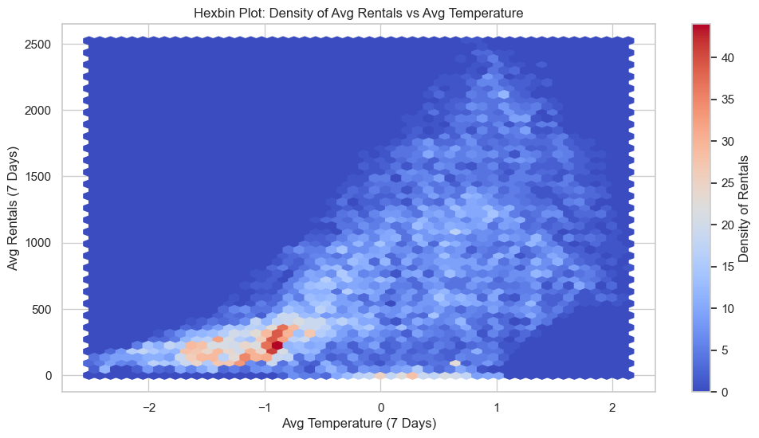

```python
# Creating an Hexbin plot to visualize the density of Avg Rentals vs Avg Temperature
plt.figure(figsize=(12, 6))
plt.hexbin(
    bike_data['Avg Temperature 7days'],
    bike_data['Avg Rentals 7days'],
    gridsize=50,
    cmap='coolwarm',
    reduce_C_function=np.mean,
)
plt.colorbar(label='Density of Rentals')
plt.xlabel('Avg Temperature (7 Days)')
plt.ylabel('Avg Rentals (7 Days)')
plt.title('Hexbin Plot: Density of Avg Rentals vs Avg Temperature')
plt.show()
```

Finally I created other 4 new features which represent the 4 parts of the day. This anaysis aims to explore any possible correlation between my target variable and possible differences during the day hours:

```python
# Initialize the columns with zeros
bike_data['Morning'] = 0
bike_data['Afternoon'] = 0
bike_data['Evening'] = 0
bike_data['Night'] = 0

# Populate the columns based on the hour
bike_data.loc[(bike_data['Hour'] >= 6) & (bike_data['Hour'] < 12), 'Morning'] = 1
bike_data.loc[(bike_data['Hour'] >= 12) & (bike_data['Hour'] < 18), 'Afternoon'] = 1
bike_data.loc[(bike_data['Hour'] >= 18) & (bike_data['Hour'] < 22), 'Evening'] = 1
bike_data.loc[(bike_data['Hour'] >= 22) | (bike_data['Hour'] < 6), 'Night'] = 1

# Verify the changes
bike_data.head()
```

|  | Rented Bike Count | Hour | Temperature(°C) | Humidity(%) | Wind speed (m/s) | Visibility (10m) | Solar Radiation (MJ/m2) | Year | Month | Day | ... | Total Rentals Month | Expanding Avg Temperature | Expanding Total Rentals | Expanding Avg Rentals | Avg Temperature 7days | Avg Rentals 7days | Morning | Afternoon | Evening | Night |
| --- | --- | --- | --- | --- | --- | --- | --- | --- | --- | --- | --- | --- | --- | --- | --- | --- | --- | --- | --- | --- | --- |
| 0 | 254 | 0 | -1.513957 | -1.042483 | 0.616347 | 0.925871 | -0.737679 | 2017 | 12 | 1 | ... | 185330 | -1.513957 | 254.0 | 254.000000 | -1.513957 | 254.000000 | 0 | 0 | 0 | 1 |
| 1 | 204 | 1 | -1.539074 | -0.993370 | -0.924040 | 0.925871 | -0.737679 | 2017 | 12 | 1 | ... | 185330 | -1.526516 | 458.0 | 229.000000 | -1.526516 | 229.000000 | 0 | 0 | 0 | 1 |
| 2 | 173 | 2 | -1.580936 | -0.944257 | -0.641965 | 0.925871 | -0.737679 | 2017 | 12 | 1 | ... | 185330 | -1.544656 | 631.0 | 210.333333 | -1.544656 | 210.333333 | 0 | 0 | 0 | 1 |
| 3 | 107 | 3 | -1.597680 | -0.895144 | -0.779289 | 0.925871 | -0.737679 | 2017 | 12 | 1 | ... | 185330 | -1.557912 | 738.0 | 184.500000 | -1.557912 | 184.500000 | 0 | 0 | 0 | 1 |
| 4 | 78 | 4 | -1.580936 | -1.091596 | 0.698730 | 0.925871 | -0.737679 | 2017 | 12 | 1 | ... | 185330 | -1.562517 | 816.0 | 163.200000 | -1.562517 | 163.200000 | 0 | 0 | 0 | 1 |

5 rows × 28 columns

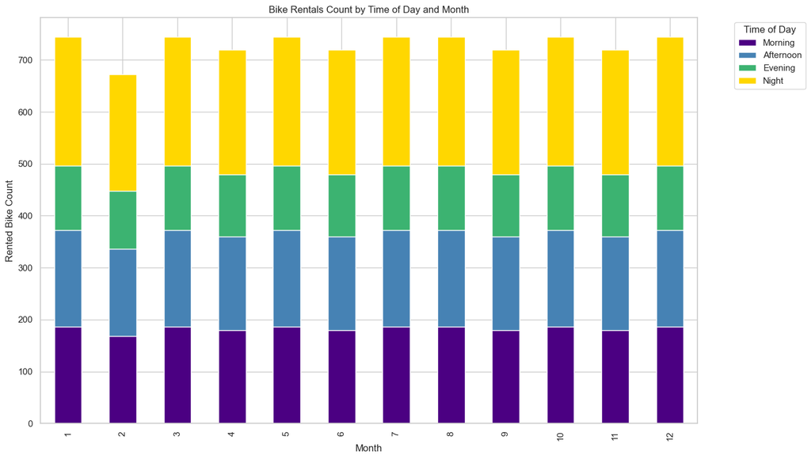

```python
# Grouping data by month and summing up rentals for each part of the day
stacked_data = bike_data.groupby('Month')[['Morning', 'Afternoon', 'Evening', 'Night']].sum()

# Create a stacked bar plot
fig, ax = plt.subplots(figsize=(14, 8))

# Plot the stacked bar plot
stacked_data.plot(kind='bar', stacked=True, ax=ax, color=['#4B0082', '#4682B4', '#3CB371', '#FFD700'])

# Set labels and title
ax.set_title('Bike Rentals Count by Time of Day and Month')
ax.set_xlabel('Month')
ax.set_ylabel('Rented Bike Count')
ax.legend(title='Time of Day', bbox_to_anchor=(1.05, 1), loc='upper left')

# Improve layout
plt.tight_layout()
plt.show()
```

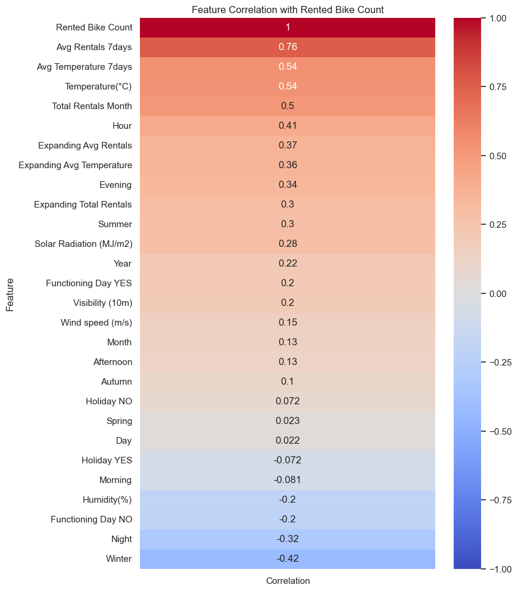

```python
# Compute the correlation matrix
corr_matrix = bike_data.corr()

# Sort the correlation values with respect to the target variable
target_corr = corr_matrix["Rented Bike Count"].sort_values(ascending=False)

# Create a DataFrame to visualize only the sorted correlations with the target
target_corr_df = target_corr.reset_index().rename(columns={"index": "Feature", "Rented Bike Count": "Correlation"})

# Plotting the heatmap
plt.figure(figsize=(8, 12))
sns.heatmap(target_corr_df.set_index("Feature"), annot=True, cmap="coolwarm", center=0, vmin=-1, vmax=1)
plt.title("Feature Correlation with Rented Bike Count")
plt.show()
```

This final **heatmap** shows the correlation of various features with the target variable, Rented Bike Count. It confirms that the feature engineering was effective, as new features like **'Avg Rentals 7days'** (0.76 correlation) and **'Avg Temperature 7days'** (0.54 correlation) exhibit strong positive correlations with the target. Other engineered features such as **'Expanding Avg Rentals'**, **'Expanding Avg Temperature'** and **'Total Rentals Month'** also show moderate correlations, indicating they provide valuable predictive power. Overall, these high correlation values suggest that the newly created features contribute positively to the model’s predictive accuracy.

# MODEL SELECTION, TRAINING AND TESTING

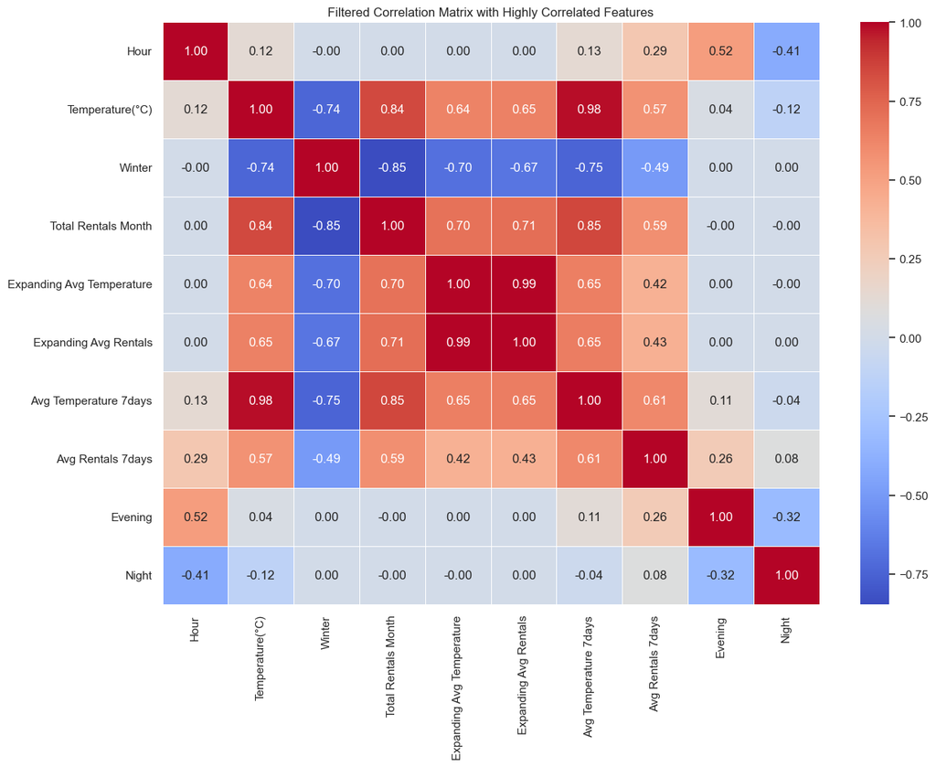

```
Highly correlated features with the target: ['Hour', 'Temperature(°C)', 'Winter', 'Total Rentals Month', 'Expanding Avg Temperature', 'Expanding Avg Rentals', 'Avg Temperature 7days', 'Avg Rentals 7days', 'Evening', 'Night']
```

```python
# Calculate the correlation matrix
corr_matrix = bike_data.corr()

# Filter the matrix to only include features that are highly correlated with 'Rented Bike Count'
target_corr = corr_matrix['Rented Bike Count']
relevant_features = target_corr[abs(target_corr) > 0.3].index.tolist()

# Remove the target itself from the list of features
if 'Rented Bike Count' in relevant_features:
    relevant_features.remove('Rented Bike Count')

# Create a filtered correlation matrix without the target variable
filtered_corr = corr_matrix.loc[relevant_features, relevant_features]

# Plot the filtered correlation matrix
plt.figure(figsize=(14, 10))
sns.heatmap(filtered_corr, annot=True, cmap='coolwarm', fmt='.2f', linewidths=0.5)
plt.title('Filtered Correlation Matrix with Highly Correlated Features')
plt.show()

# Print the highly correlated features
print("Highly correlated features with the target:", relevant_features)
```

This **correlation matrix** displays the relationships between selected features that are highly correlated with the target variable 'Rented Bike Count'. Features like 'Hour', 'Temperature(°C)', and 'Avg Rentals 7days' show notable correlations with the target, suggesting they may be valuable for the model.

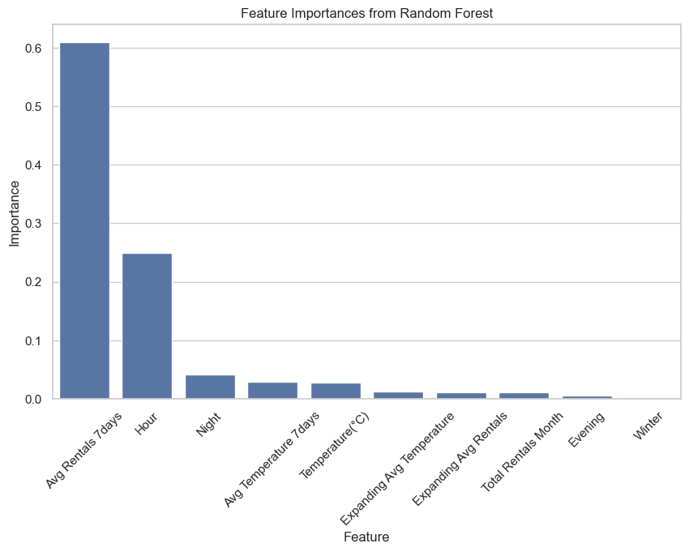

```python
# Define the features and target variable
selected_features = [
    'Hour', 'Temperature(°C)', 'Winter', 'Total Rentals Month',
    'Expanding Avg Temperature', 'Expanding Avg Rentals',
    'Avg Temperature 7days', 'Avg Rentals 7days',
    'Evening', 'Night'
]
X = bike_data[selected_features]
y = bike_data['Rented Bike Count']

# Train a Random Forest model
from sklearn.ensemble import RandomForestRegressor
rf = RandomForestRegressor(random_state=42)
rf.fit(X, y)

# Get feature importances
feature_importances = pd.DataFrame(
    rf.feature_importances_,
    index=X.columns,
    columns=['Importance']
).sort_values('Importance', ascending=False)

# Plot feature importances
plt.figure(figsize=(10, 6))
sns.barplot(x=feature_importances.index, y=feature_importances['Importance'])
plt.title('Feature Importances from Random Forest')
plt.xticks(rotation=45)
plt.xlabel('Feature')
plt.ylabel('Importance')
plt.show()
```

From the output of this **feature importance plot** we can understand that 'Avg Rentals 7days' and 'Hour' are the most influential features in predicting 'Rented Bike Count', with 'Avg Rentals 7days' having a significantly higher impact than all other features. The remaining features, such as 'Night', 'Avg Temperature 7days', and others, contribute much less to the model's predictions, indicating their lower relevance for the target variable in this context.